# Prédiction du prix de vente immobilier

Baba Galle Ndiaye et Sansan

# Introduction :

L’immobilier représente l’un des marchés les plus importants de l’économie française. La prédiction du prix d’un bien immobilier est un enjeu majeur pour les acheteurs, vendeurs, notaires et investisseurs. Elle permet d’éviter les surestimations ou sous-estimations de valeur et de mieux comprendre les dynamiques du marché.

**Problématique**

Le marché immobilier est influencé par une grande variété de facteurs structurels, géographiques et administratifs. Dans ce contexte, la question centrale de cette étude est la suivante :

**Quels sont les déterminants du prix de vente immobilier et dans quelle mesure les caractéristiques du bien permettent-elles de prédire ce prix ?**

Cette problématique s’inscrit dans un cadre où les données disponibles sont hétérogènes, comportant à la fois des variables quantitatives (surfaces, nombre de pièces), qualitatives (type de local, commune) et administratives (code postal, section cadastrale).

**Objectif de l’étude**

L’objectif principal est d’**analyser les relations entre les caractéristiques des biens immobiliers et leur prix de vente**, puis d’évaluer la capacité prédictive de différents modèles statistiques :

- Régression linéaire (LM)
- Modèle linéaire généralisé (GLM gaussien, lien log)
- Méthodes de réduction dimensionnelle (PCR, PLS)
- Méthodes de régularisation (Ridge, Lasso, Elastic Net)

L’étude vise à déterminer si ces modèles permettent d’améliorer la prédiction du prix et d’identifier les variables les plus influentes.

**Variables d’intérêt**

Le jeu de données initial contient **1387077 observations et 43 variables** .  
Certaines variables sont administratives ou textuelles et ne sont pas pertinentes pour la modélisation.  
Les variables retenues sont celles qui présentent un lien potentiel avec la valeur foncière.

**Variables quantitatives**

- **Surface.reelle.bati** : surface bâtie en m²
- **Surface.Carrez.du.1er.lot** : surface Carrez principale
- **Surface.terrain** : surface du terrain en m²
- **Nombre.pieces.principales** : nombre de pièces
- **Valeur foncière** (transformée en *log_prix*)

**Variables qualitatives**

- **Code.postal** : localisation géographique
- **Code.type.local** : type de bien (maison, appartement, dépendance…)
- **Commune**, **Type.de.voie**, **Nature.mutation** (non retenues dans les modèles finaux)

**Variable cible**

- **log_prix** : logarithme du prix de vente (valeur foncière)

# Partie 1 – Exploration et Préparation des Données :

## 1.1 Chargement et premier aperçu :

La première étape consiste à charger les données et à en obtenir une vue d’ensemble statistique afin d’identifier les problèmes de qualité : valeurs manquantes, valeurs aberrantes, types de variables incorrects.

**Chargement des données :**

```
##         Identifiant.de.document Reference.document X1.Articles.CGI
## 1237518                      NA                 NA              NA
## 134058                       NA                 NA              NA
## 1172598                      NA                 NA              NA
## 685285                       NA                 NA              NA
## 1274894                      NA                 NA              NA
## 1242203                      NA                 NA              NA
##         X2.Articles.CGI X3.Articles.CGI X4.Articles.CGI X5.Articles.CGI
## 1237518              NA              NA              NA              NA
## 134058               NA              NA              NA              NA
## 1172598              NA              NA              NA              NA
## 685285               NA              NA              NA              NA
## 1274894              NA              NA              NA              NA
## 1242203              NA              NA              NA              NA
##         No.disposition Date.mutation                    Nature.mutation
```

[output cut: 69 more lines]

**Premier aperçu :**

```
## [1] 200000     43
```

Nous avons garder que **200000 observations et 43 variables** pour faire notre traitement de données

```
## 'data.frame':    200000 obs. of  43 variables:
##  $ Identifiant.de.document   : logi  NA NA NA NA NA NA ...
##  $ Reference.document        : logi  NA NA NA NA NA NA ...
##  $ X1.Articles.CGI           : logi  NA NA NA NA NA NA ...
##  $ X2.Articles.CGI           : logi  NA NA NA NA NA NA ...
##  $ X3.Articles.CGI           : logi  NA NA NA NA NA NA ...
##  $ X4.Articles.CGI           : logi  NA NA NA NA NA NA ...
##  $ X5.Articles.CGI           : logi  NA NA NA NA NA NA ...
##  $ No.disposition            : int  1 2 1 1 1 1 2 1 1 1 ...
##  $ Date.mutation             : chr  "01/02/2025" "20/03/2025" "24/04/2025" "22/01/2025" ...
##  $ Nature.mutation           : chr  "Vente" "Echange" "Vente" "Vente" ...
##  $ Valeur.fonciere           : num  204000 230 165000 125000 3412 ...
##  $ No.voie                   : int  44 NA 19 111 NA NA NA 4 2 1 ...
##  $ B.T.Q                     : chr  "" "" "" "" ...
##  $ Type.de.voie              : chr  "CHE" "" "CHE" "RUE" ...
```

[output cut: 29 more lines]

```
##  Identifiant.de.document Reference.document X1.Articles.CGI X2.Articles.CGI
##  Mode:logical            Mode:logical       Mode:logical    Mode:logical
##  NA's:200000             NA's:200000        NA's:200000     NA's:200000
##
##
##
##
##
##  X3.Articles.CGI X4.Articles.CGI X5.Articles.CGI No.disposition
##  Mode:logical    Mode:logical    Mode:logical    Min.   : 1.000
##  NA's:200000     NA's:200000     NA's:200000     1st Qu.: 1.000
##                                                  Median : 1.000
##                                                  Mean   : 1.063
##                                                  3rd Qu.: 1.000
##                                                  Max.   :37.000
##
##  Date.mutation      Nature.mutation    Valeur.fonciere        No.voie
##  Length:200000      Length:200000      Min.   :        0   Min.   :   1.0
##  Class :character   Class :character   1st Qu.:    59219   1st Qu.:   8.0
##  Mode  :character   Mode  :character   Median :   157502   Median :  24.0
##                                        Mean   :   699433   Mean   : 639.3
##                                        3rd Qu.:   295000   3rd Qu.:  94.0
##                                        Max.   :317290816   Max.   :9999.0
##                                        NA's   :1986        NA's   :74102
##     B.T.Q           Type.de.voie        Code.voie             Voie
##  Length:200000      Length:200000      Length:200000      Length:200000
##  Class :character   Class :character   Class :character   Class :character
##  Mode  :character   Mode  :character   Mode  :character   Mode  :character
##
##
##
##
##   Code.postal      Commune          Code.departement    Code.commune
##  Min.   : 1000   Length:200000      Length:200000      Min.   :  1.0
##  1st Qu.:27290   Class :character   Class :character   1st Qu.: 75.0
##  Median :49140   Mode  :character   Mode  :character   Median :168.0
##  Mean   :49502                                         Mean   :206.3
##  3rd Qu.:74370                                         3rd Qu.:294.0
##  Max.   :97490                                         Max.   :909.0
##  NA's   :1748
```

[output cut: 49 more lines]

```
##  Min.   : 0.00             Length:200000      Length:200000
##  1st Qu.: 0.00             Class :character   Class :character
##  Median : 0.00             Mode  :character   Mode  :character
##  Mean   : 1.71
##  3rd Qu.: 3.00
##  Max.   :83.00
##  NA's   :82765
##  Surface.terrain
##  Min.   :      0
##  1st Qu.:    252
##  Median :    641
##  Mean   :   2936
##  3rd Qu.:   1920
##  Max.   :1132980
##  NA's   :64369
```

## 1.2 Gestion des valeurs manquantes :

L’analyse du résumé statistique révèle un taux de valeurs manquantes très élevé pour certaines variables (X1 à X5 Articles.CGI : 100% de NA). Ces variables seront supprimées. Pour les autres, une stratégie d’imputation sera appliquée.

**Visualisation :**

```
## # A tibble: 43 × 2
##    variable                   pct_na
##    <chr>                       <dbl>
##  1 Identifiant.de.document     100
##  2 Reference.document          100
##  3 X1.Articles.CGI             100
##  4 X2.Articles.CGI             100
##  5 X3.Articles.CGI             100
##  6 X4.Articles.CGI             100
##  7 X5.Articles.CGI             100
##  8 Identifiant.local           100
##  9 Surface.Carrez.du.5eme.lot   99.9
## 10 Surface.Carrez.du.4eme.lot   99.9
## # ℹ 33 more rows
```

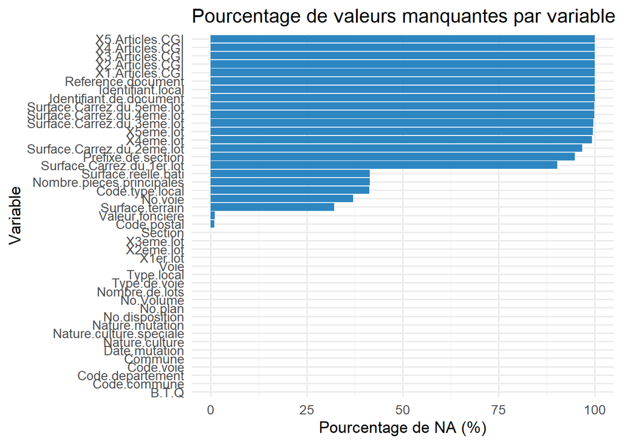

**Suppression des variables avec > 95% de valeur manquante**

```
## [1] 3550874
```

## 1.3 Traitement des valeurs aberrantes:

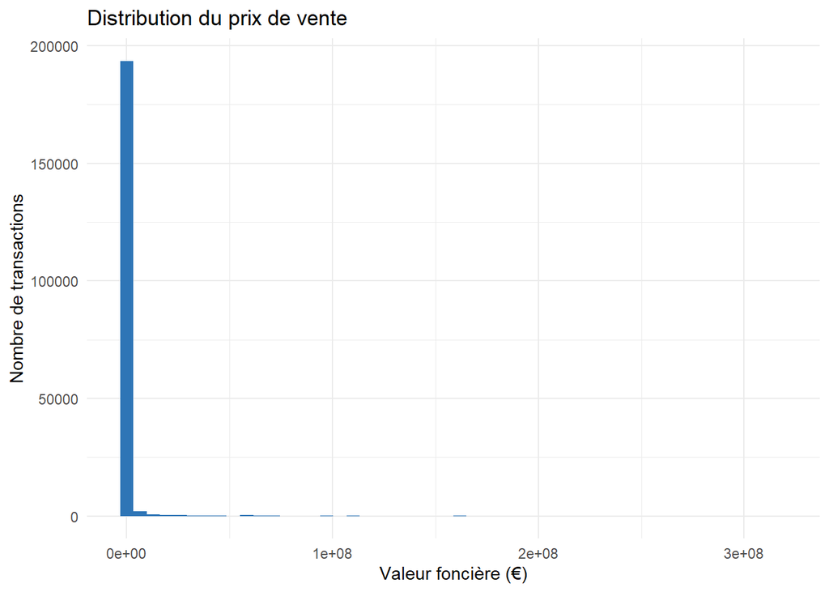

**on utilise la méthode d’imputation par la median :**

```
## [1] 0
```

# Partie 2 – Sélection et analyses des variables :

On va maintenant **symétriser les variables quantitatives** à l’aide de la méthode du boxcox et créer un nouveau data frame à partir de cela. On compare ensuite les histogrammes et boîtes à moustaches d’origine aux graphiques sur les données symétrisées.

La méthode de boxcox s’appuie sur la *Transformée de boxcox* suivante :

$$B(x, \lambda) =
\begin{cases}
\frac{x^{\lambda} - 1}{\lambda} & \quad \text{si $\lambda \neq 0$}\\
\log(x) & \quad \text{si $\lambda = 0$}
\end{cases}$$

## 2.1 Variable cible :

La variable à prédire est Valeur.fonciere, qui représente le prix de vente du bien immobilier tel qu’enregistré dans l’acte notarié. Sa distribution étant fortement asymétrique à droite, il est recommandé d’appliquer une transformation logarithmique avant la modélisation.

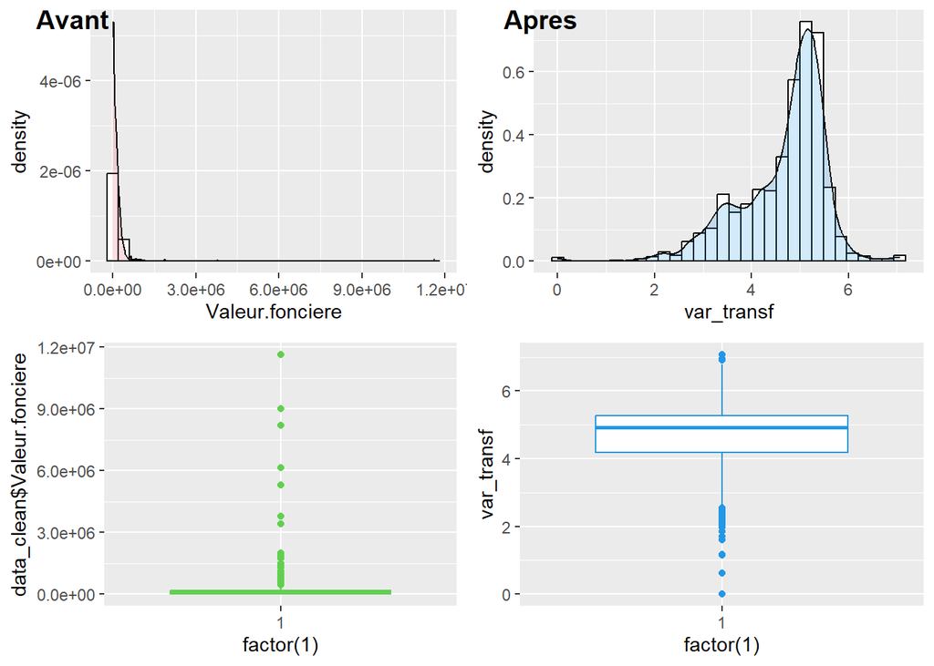

## 2.2 Préparation du jeu de données :

```
##    log_prix Surface.reelle.bati Nombre.pieces.principales  Type.local
## 1 12.567237                 126                         5      Maison
## 2  9.210340                  33                         1
## 3 12.611538                  63                         2 Appartement
## 4 11.798104                   0                         0  Dépendance
## 5  9.036506                  33                         1
## 6 12.100712                  66                         3      Maison
##   Nature.mutation Surface.terrain Code.departement Code.postal Nombre.de.lots
## 1           Vente            1215               63       63800              0
## 2           Vente             250               63       63120              0
## 3           Vente             420               63       63340              0
## 4           Vente            1187               63       63250              0
## 5           Vente             365               63       63680              0
## 6           Vente             549               63       63360              0
##   Surface.Carrez.du.1er.lot Code.type.local
## 1                     58.26               1
## 2                     58.26               2
## 3                     58.26               2
## 4                     58.26               3
## 5                     58.26               2
## 6                     58.26               1
```

## 2.3 Visualistion des variables quantitatives

**Surface.reelle.bati**

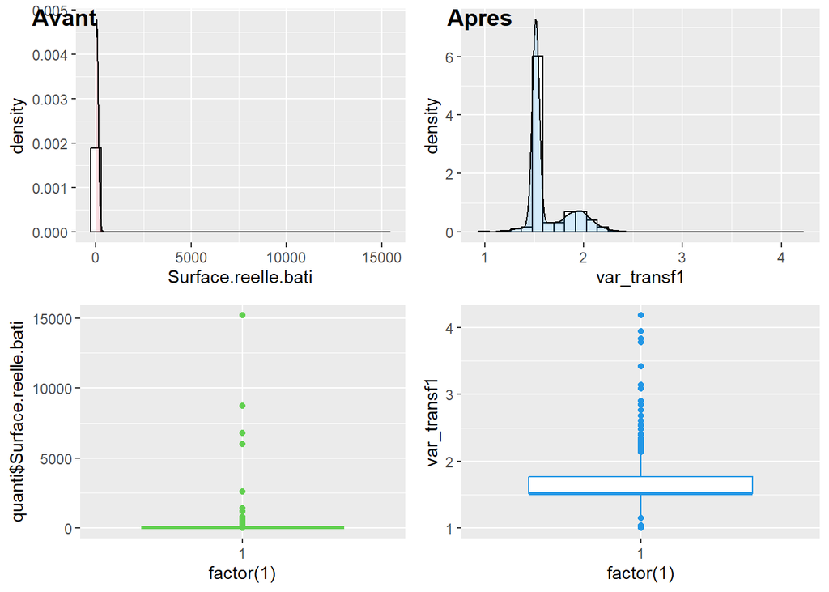

**Nombre.pieces.principales**

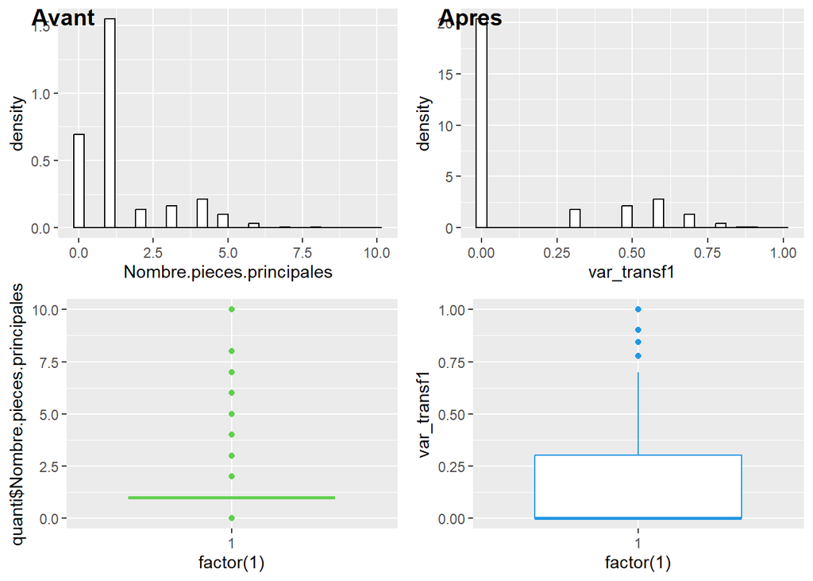

**Surface.terrain**

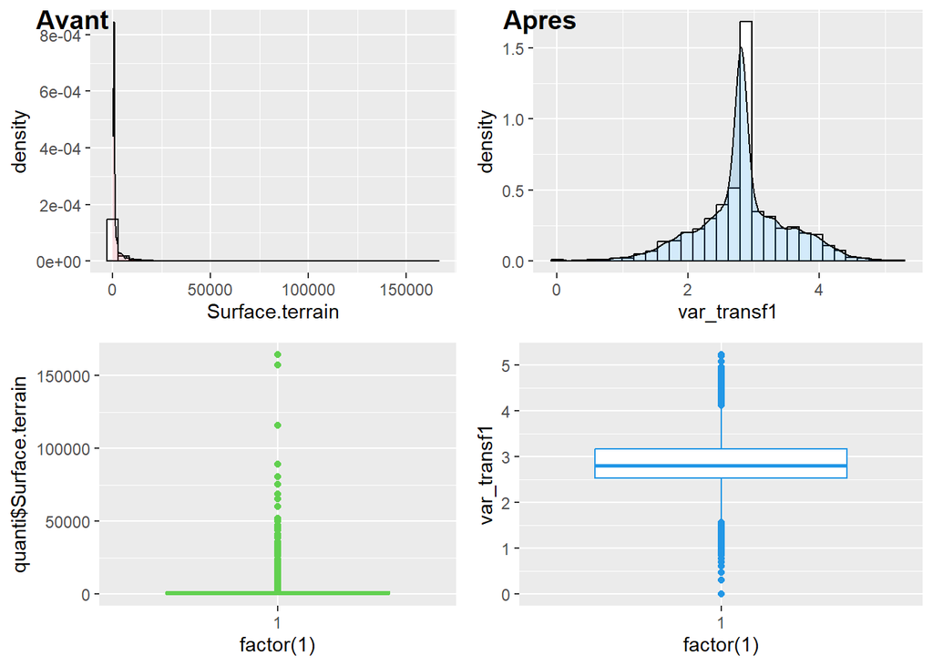

**Code.postal**

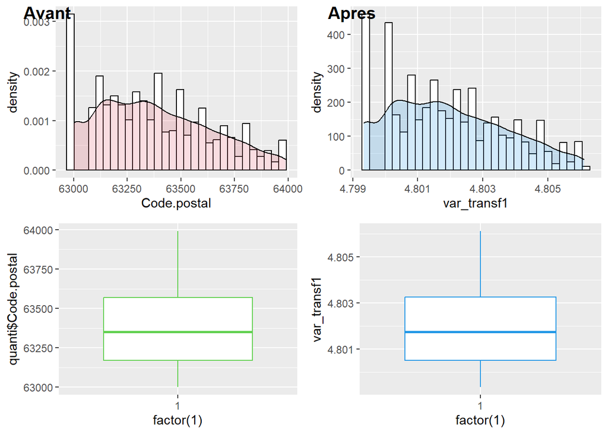

**Nombre.de.lots**

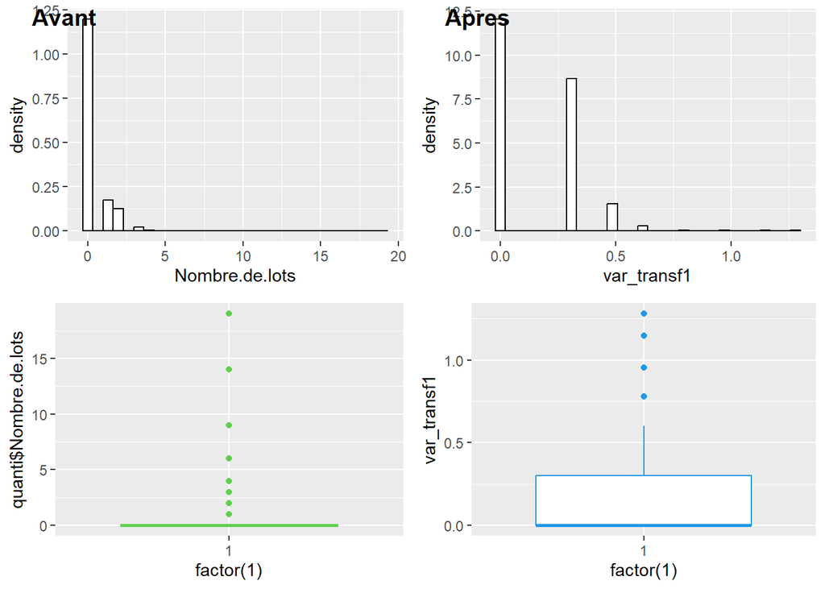

**Surface.Carrez.du.1er.lot**

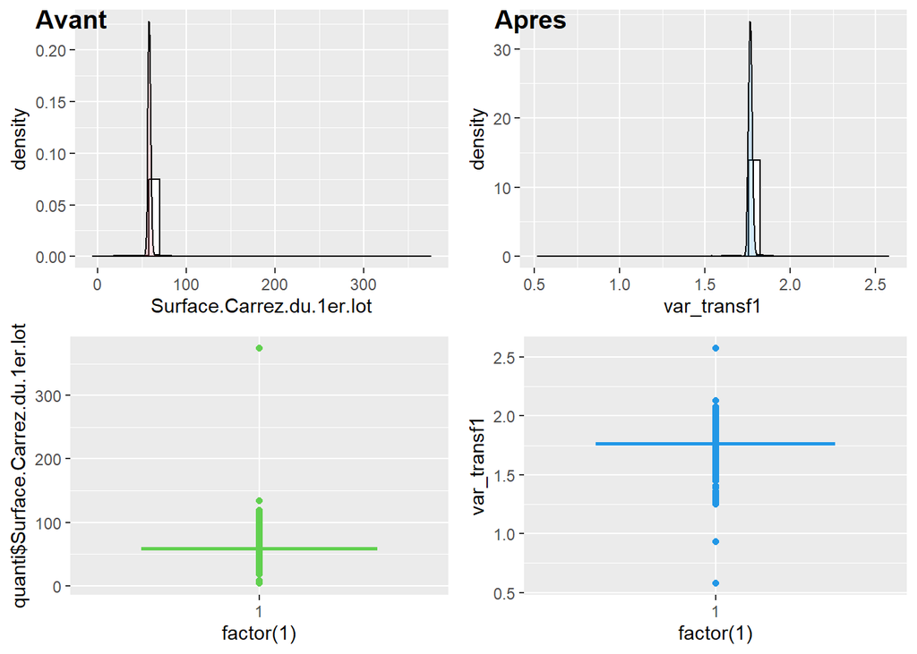

**Code.type.local**

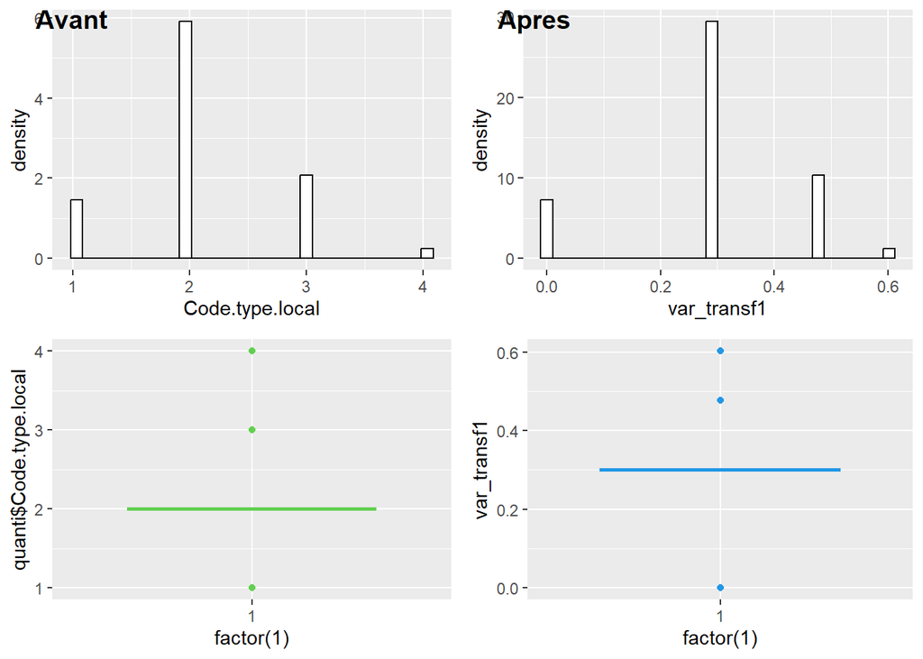

Nous avons appliquer la symétrisation de toutes les variables et aprés traitement on se retrouve avec **2625 observation et 11 variables**.

## 2.4 Corrélations

*Matrice de corrélation avec la valeur foncière* et *la valeur log*

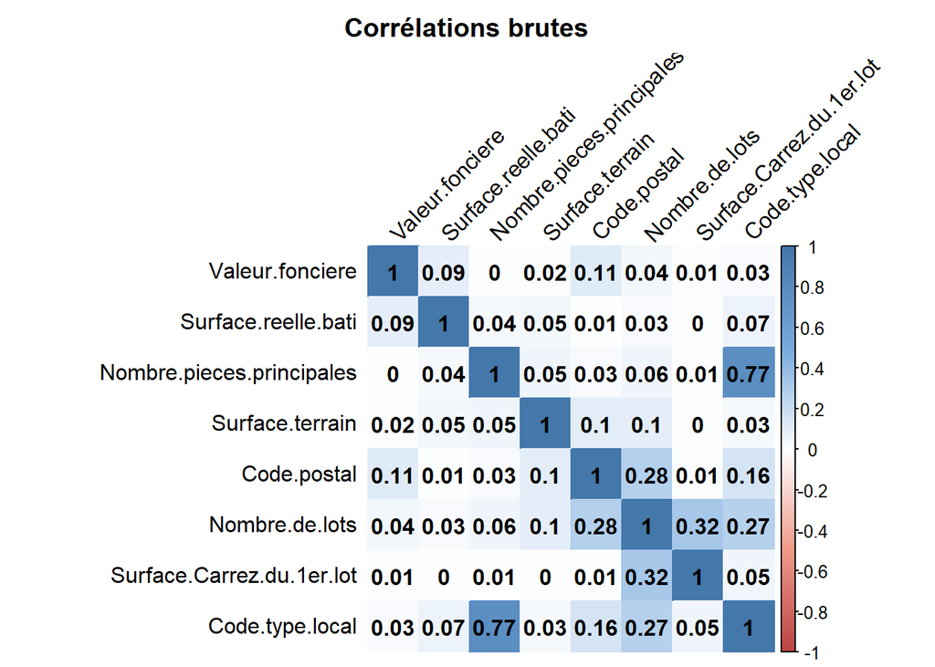

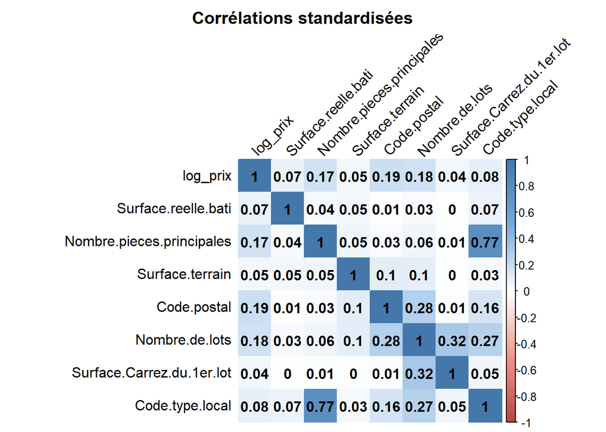

## 2.5 ACP

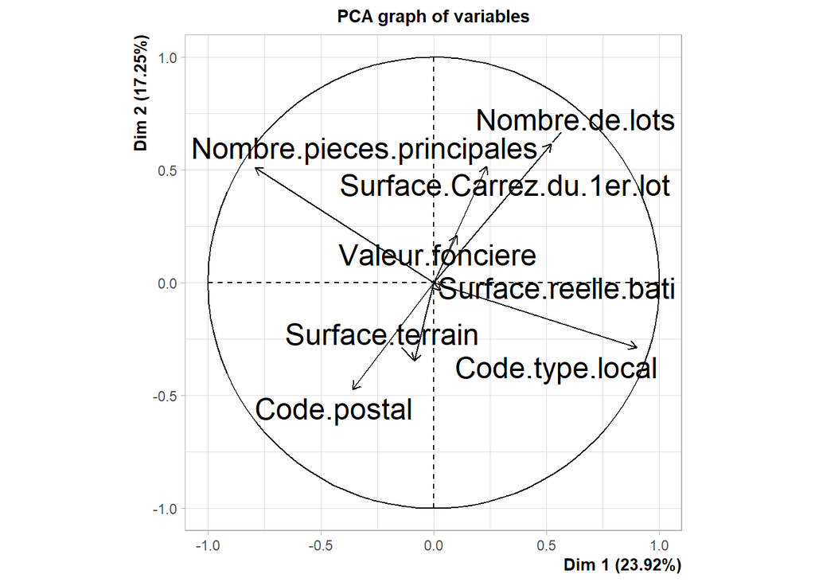

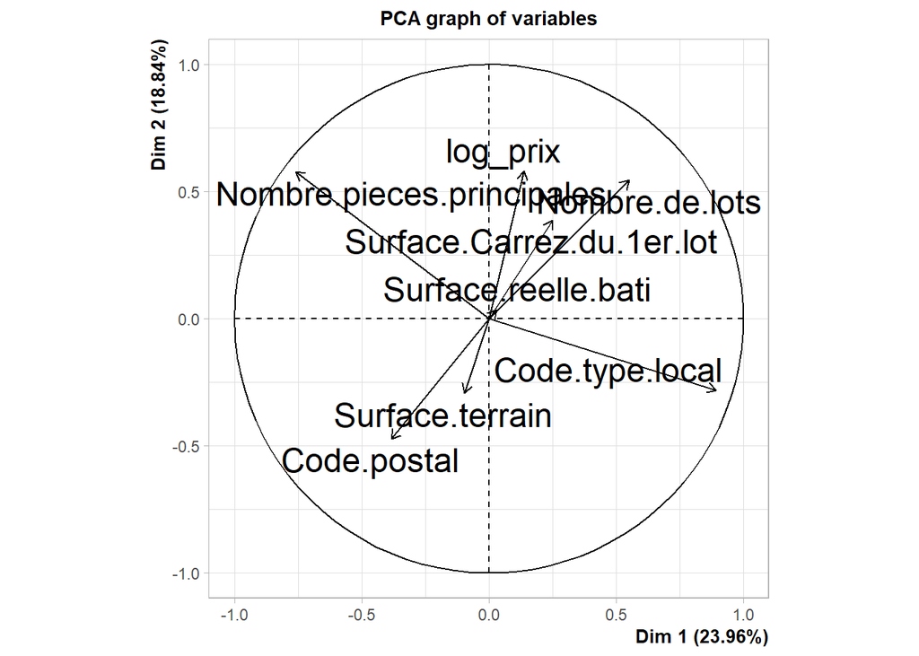

**Tableau récapitulatif des corrélations et pour les contributions ACP**

```
##                                            Variable Correlation_avec_log_prix
## Surface.reelle.bati             Surface.reelle.bati                     0.074
## Nombre.pieces.principales Nombre.pieces.principales                     0.173
## Surface.terrain                     Surface.terrain                    -0.046
## Code.postal                             Code.postal                    -0.189
## Nombre.de.lots                       Nombre.de.lots                     0.175
## Surface.Carrez.du.1er.lot Surface.Carrez.du.1er.lot                     0.043
## Code.type.local                     Code.type.local                     0.081
```

```
##                           Dim.1 Dim.2
## Surface.reelle.bati        0.02  0.58
## Nombre.pieces.principales 33.49 17.82
## Surface.terrain            0.35  9.24
## Code.postal                6.38 14.98
## Nombre.de.lots            13.99 29.98
## Surface.Carrez.du.1er.lot  2.85 21.87
## Code.type.local           42.92  5.53
```

# Partie 3 – Modélisation Statistique :

## 1 - Régression linéaire multiple :

### 1.1 La théorie

#### **a) Le modèle**

On a le modèle suivant :

$$Y_{i} = \sum_{j = 0}^{p} a_{j}X_{i,j} +
\epsilon_{i}$$
pour $i = 1, ..., n$

où $X_{0,j} = 1$

La variable Y est la variable à expliquer et les variables $X_{i}$ sont les variables explicatives.  
Les variables $a_{j}$, (où $j = 0, ..., p$) sont les paramètres à estimer de notre modèle.  
Les $\epsilon_{i}$ sont les erreurs.

On peut aussi écrire ce modèle sous la forme matricielle suivante : $Y = XA + \epsilon$

#### **b) Les hypothèses**

Nous devrons vérifier les hypothèses suivantes :

*Hypothèses à priori :*

1. $r(X_{i},Y) != 0$ (toutes les corrélations ne doivent pas être nulles)
2. La matrice X est de plein rang : les $X_{i}$ ne sont pas colinéaires (ils sont linéairement indépendants) : cela assure que $X^{T}X$ est inversible.
3. n ? p + 1 il faut savoir ce qu’on a à la place de ? (<, >, =) ce qui revient à résoudre le modèle de régression linéaire c’est-à-dire une équation à n équations et p inconnues
- si n = p + 1, la “droite de régression” est celle qui passe par tous les points
- si n > p + 1, une unique solution
- si n < p + 1, une infinité de solution

*Hypothèses a posteriori :*

4. $\mathbb{E}(\epsilon_{i})=0$, $Var(\epsilon_{i})=\sigma²)$ et les $\epsilon_{i}$ sont non corrélés. De plus, on doit avoir $cov(X_{i}, \epsilon_{i}) = 0$
5. Les $\epsilon_{i}$ sont normales.

### 1.2 Estimation des moindres carrés ordinaire (MCO) :

Un **estimateur Â** du vecteur A peut être trouvé par **la méthode d’estimation des moindres carrés ordinaire** (possible grâce à l’hypothèse numéro 2).  
L’objectif est de trouver le paramètre A qui minimise la somme des carrés des erreurs entre les valeurs prévues et observées.

Voici son expression $Â = (X^{T}X)^{-1}X^{T}Y$

**Cet estimateur a les propriétés suivantes :** 1. Il est sans biais : $\mathbb{E}(Â) = A$

2. C’est le le meilleur estimateur sans biais linéaire (il est de variance minimum) : il est appelé *BLUE* (Best Linear Unbiased Estimator).
3. Sous l’hypothèse de normalité des $\epsilon_{i}$, Â est l’estimateur du maximum de vraisemblance. Il est donc efficace. De plus, Â ~ $\mathcal{N}(A, \sigma²(X^{T}X)^{-1})$
4. Â $\to^{\mathcal{L}} \mathcal{N}(A, \dfrac{\sigma²Q^{-1}}{n})$. Si l’hypothèse de normalité n’est pas vérifiée mais que l’hypothèse $\dfrac{X^{T}X}{n} \to Q$ (inversible) est vérifiée, le résultat est valide.
5. Â est convergent en probabilité.

**Loi des paramètres :**

- $Var(Â) = \sigma²(X^{T}X)^{-1}$
- La variance des $a_{j}$ est $\sigma²_{a_{j}} = [\sigma²(X^{T}X)^{-1}]_{j,j}$ On peut remplacer $\sigma²$ par son estimateur sans biais $s²$.

### 1.3 Application

#### 1.3.1 Création du modèle

Voici les différentes variables qui constituent notre problème de régression linéaire :

**Variable à expliquer** : le prix immobilier, que l’on va noter Y

**Variables explicatives** :  
- Nombre.pieces.principale, notée $X_{1}$  
- Code.posta, noté $X_{2}$  
- Surface.Carrez.du.1er.lo - Surface.reelle.bati - Surface.terrain - Nombre.de.lots - Code.type.local

**Définissons tout d’abord les matrices de ce système :**

```
## [1] "La matrice X est de la forme :"
```

```
##      ones_vector
## [1,]           1 126 5 1215 63800 0 58.26 1
## [2,]           1  33 1  250 63120 0 58.26 2
## [3,]           1  63 2  420 63340 0 58.26 2
## [4,]           1   0 0 1187 63250 0 58.26 3
## [5,]           1  33 1  365 63680 0 58.26 2
## [6,]           1  66 3  549 63360 0 58.26 1
```

#### 1.3.2 Vérification des hypothèses a priori :

Nous allons vérifier les différentes hypothèses de notre problème de régression linéaire :

```
## [1] "Toutes les hypothèses ont été vérifiées"
```

### 1.3.3 Application de l’estimation des moindres carrés :

Ici, on construit Â de façon matriciel puis le résidu de nos erreurs.

```
## [1] "Matrice Â :"
```

```
##                      [,1]
## ones_vector  6.536606e+01
##              1.318904e-04
##              7.368630e-01
##              3.651296e-06
##             -9.231362e-04
##              1.351660e-01
##             -1.231605e-03
##              1.359915e+00
```

### Modèle 1 : Régression linéaire (LM)

Le modèle linéaire estimé est :

$$\log(prix_i) =
\beta_0
+ \beta_1 \cdot \text{Surface.reelle.bati}_i
+ \beta_2 \cdot \text{Nombre.pieces.principales}_i
+ \beta_3 \cdot \text{Surface.terrain}_i
+ \beta_4 \cdot \text{Code.postal}_i
+ \beta_5 \cdot \text{Nombre.de.lots}_i
+ \beta_6 \cdot \text{Surface.Carrez.du.1er.lot}_i
+ \beta_7 \cdot \text{Code.type.local}_i
+ \varepsilon_i$$

avec :

$$\varepsilon_i \sim \mathcal{N}(0, \sigma^2)$$

#### 1.3.4 Utilisation de la fonction lm :

```
##
## Call:
## lm(formula = log_prix ~ quanti$Surface.reelle.bati + quanti$Nombre.pieces.principales +
##     quanti$Surface.terrain + quanti$Code.postal + quanti$Nombre.de.lots +
##     quanti$Surface.Carrez.du.1er.lot + quanti$Code.type.local,
##     data = sym_quanti)
##
## Coefficients:
##                      (Intercept)        quanti$Surface.reelle.bati
##                        6.537e+01                         1.319e-04
## quanti$Nombre.pieces.principales            quanti$Surface.terrain
##                        7.369e-01                         3.651e-06
##               quanti$Code.postal             quanti$Nombre.de.lots
##                       -9.231e-04                         1.352e-01
## quanti$Surface.Carrez.du.1er.lot            quanti$Code.type.local
##                       -1.232e-03                         1.360e+00
```

```
##
## Call:
## lm(formula = log_prix ~ quanti$Surface.reelle.bati + quanti$Nombre.pieces.principales +
##     quanti$Surface.terrain + quanti$Code.postal + quanti$Nombre.de.lots +
##     quanti$Surface.Carrez.du.1er.lot + quanti$Code.type.local,
##     data = sym_quanti)
##
## Residuals:
##      Min       1Q   Median       3Q      Max
## -10.5062  -0.9692   0.3030   1.2274   5.8775
##
## Coefficients:
##                                    Estimate Std. Error t value Pr(>|t|)
## (Intercept)                       6.537e+01  9.415e+00   6.943 4.83e-12 ***
## quanti$Surface.reelle.bati        1.319e-04  9.529e-05   1.384  0.16644
## quanti$Nombre.pieces.principales  7.369e-01  4.149e-02  17.758  < 2e-16 ***
## quanti$Surface.terrain            3.651e-06  4.848e-06   0.753  0.45145
## quanti$Code.postal               -9.231e-04  1.483e-04  -6.226 5.56e-10 ***
## quanti$Nombre.de.lots             1.352e-01  4.903e-02   2.757  0.00588 **
## quanti$Surface.Carrez.du.1er.lot -1.232e-03  4.500e-03  -0.274  0.78435
## quanti$Code.type.local            1.360e+00  9.315e-02  14.599  < 2e-16 ***
## ---
## Signif. codes:  0 '***' 0.001 '**' 0.01 '*' 0.05 '.' 0.1 ' ' 1
##
## Residual standard error: 1.877 on 2617 degrees of freedom
## Multiple R-squared:  0.1599, Adjusted R-squared:  0.1577
## F-statistic: 71.16 on 7 and 2617 DF,  p-value: < 2.2e-16
```

### 1.4 Intervalles de confiance de chaque paramètre :

L’intervalle de confiance au niveau $1 - \alpha$ est : I = [$â_{j} \pm \hat \sigma_{a_{j}} \times t_{n-p-1}(1-\dfrac{\alpha}{2})$] où t est le fractile d’ordre $1-\dfrac{\alpha}{2}$ d’une loi de Student à $n-p-1$ degrés de libertés.

où $\hat \sigma_{a_{j}}$ est est le $j^{ème}$ élément de la diagonale de la matrice $\sigma²(X^{T}X)^{-1}$.

```
## [1] "Intervalle de confiance pour le paramètre a_ 0  :"
## ones_vector ones_vector
##   -107.9828    238.7149
## [1] "Intervalle de confiance pour le paramètre a_ 1  :"
##
## 0.0001318726 0.0001319081
## [1] "Intervalle de confiance pour le paramètre a_ 2  :"
##
## 0.7334958 0.7402303
## [1] "Intervalle de confiance pour le paramètre a_ 3  :"
##
## 3.651250e-06 3.651342e-06
## [1] "Intervalle de confiance pour le paramètre a_ 4  :"
##
## -0.0009231792 -0.0009230932
## [1] "Intervalle de confiance pour le paramètre a_ 5  :"
##
## 0.1304648 0.1398672
## [1] "Intervalle de confiance pour le paramètre a_ 6  :"
##
## -0.001271210 -0.001192001
## [1] "Intervalle de confiance pour le paramètre a_ 7  :"
##
## 1.342946 1.376884
```

### 1.4 Significativité :

**Significativité simple :**

On veut tester $H_{0} : a_{0} = 0$ contre $H_{1} : a_{0} \neq 0$ … $H_{0} : a_{2} = 0$ contre $H_{1} : a_{2} \neq 0$

```
## [1] "Test de Student, p-value : 0"
```

La p-value du test de Student est largement inférieure à 5% donc le modèle dans son ensemble est statistiquement significatif.

**Significativité globale :**

On veut tester $H_{0} : a_{0} = a_{1} = a_{2} = 0$ contre $H_{1} :$ l’un des coefficients au moins n’est pas nul. En regardant les intervalles de confiance, on remarque que l’on rejette $H_{0}$ car plusieurs coefficients $a_{i}$ ont des intervalles de confiance ne contenant pas 0.

Dans la régression linéaire effectuée avec *lm*, on peut remarquer que la p-value est de très inférieure à 5% donc le modèle est globalement significatif.

### 1.5 Qualité d’ajustement du modèle

Pour voir la qualité d’ajustement de notre modèle, nous allons étudier ces différents coefficients : R², RMSE, MAE, AIC, BIC.

Dans un premier temps, nous allons choisir des modèles de façon arbitraire et allons les comparer entre eux.

Nous allons aussi comparer les valeurs trouvées pour notre modèle avec celles pour d’autres modèles :

- le modèle n°1 est le modèle que nous avions utilisé plus haut (linear)
- Y en fonction de Nombre.pieces.principales et Surface.reelle.bati (modèle 2)
- Y en fonction du Surface.terrain, Nombre.pieces.principales et Surface.reelle.bati (modèle 3)
- Y en fonction de Nombre.pieces.principales, Surface.terrain, Surface.reelle.bati et Nombre.de.lots (modèle 4)

|  | Description |
| --- | --- |
| R² | mesure la qualité de la prédiction du modèle (plus il est proche de 1, plus le modèle est bon) |
| RMSE | indique à quel point les valeurs prédites sont éloignées de nos valeurs observées |
| MAE | erreur absolue moyenne entre les valeurs prédites et observées |
| AIC | plus la valeur est faible, plus le modèle est bon |
| BIC | même principe que pour AIC |

Nous pouvons faire cela de façon automatique avec un StepAIC, qui va comparer tous les modèles possibles de sélectionner le meilleur. C’est notamment très utile lorsqu’il y a beaucoup de variables.

**StepAIC :**

**-> Sélection pas à pas ascendante (forward) :**

```
##
## Call:
## lm(formula = log_prix ~ quanti$Surface.reelle.bati + quanti$Nombre.pieces.principales +
##     quanti$Surface.terrain + quanti$Code.postal + quanti$Nombre.de.lots +
##     quanti$Surface.Carrez.du.1er.lot + quanti$Code.type.local,
##     data = sym_quanti)
##
## Residuals:
##      Min       1Q   Median       3Q      Max
## -10.5062  -0.9692   0.3030   1.2274   5.8775
##
## Coefficients:
##                                    Estimate Std. Error t value Pr(>|t|)
## (Intercept)                       6.537e+01  9.415e+00   6.943 4.83e-12 ***
## quanti$Surface.reelle.bati        1.319e-04  9.529e-05   1.384  0.16644
## quanti$Nombre.pieces.principales  7.369e-01  4.149e-02  17.758  < 2e-16 ***
## quanti$Surface.terrain            3.651e-06  4.848e-06   0.753  0.45145
## quanti$Code.postal               -9.231e-04  1.483e-04  -6.226 5.56e-10 ***
## quanti$Nombre.de.lots             1.352e-01  4.903e-02   2.757  0.00588 **
## quanti$Surface.Carrez.du.1er.lot -1.232e-03  4.500e-03  -0.274  0.78435
## quanti$Code.type.local            1.360e+00  9.315e-02  14.599  < 2e-16 ***
## ---
## Signif. codes:  0 '***' 0.001 '**' 0.01 '*' 0.05 '.' 0.1 ' ' 1
##
## Residual standard error: 1.877 on 2617 degrees of freedom
## Multiple R-squared:  0.1599, Adjusted R-squared:  0.1577
## F-statistic: 71.16 on 7 and 2617 DF,  p-value: < 2.2e-16
```

On retrouve notre modèle n°1 avec Y en fonction de X.

**-> Sélection pas à pas descendante (backward) :**

```
##
## Call:
## lm(formula = log_prix ~ quanti$Surface.reelle.bati + quanti$Nombre.pieces.principales +
##     quanti$Code.postal + quanti$Nombre.de.lots + quanti$Code.type.local,
##     data = sym_quanti)
##
## Residuals:
##      Min       1Q   Median       3Q      Max
## -10.5169  -0.9603   0.3049   1.2225   5.8644
##
## Coefficients:
##                                    Estimate Std. Error t value Pr(>|t|)
## (Intercept)                       6.504e+01  9.379e+00   6.935 5.10e-12 ***
## quanti$Surface.reelle.bati        1.360e-04  9.506e-05   1.431   0.1525
## quanti$Nombre.pieces.principales  7.334e-01  4.124e-02  17.785  < 2e-16 ***
## quanti$Code.postal               -9.187e-04  1.474e-04  -6.233 5.31e-10 ***
## quanti$Nombre.de.lots             1.294e-01  4.639e-02   2.791   0.0053 **
## quanti$Code.type.local            1.354e+00  9.275e-02  14.598  < 2e-16 ***
## ---
## Signif. codes:  0 '***' 0.001 '**' 0.01 '*' 0.05 '.' 0.1 ' ' 1
##
## Residual standard error: 1.876 on 2619 degrees of freedom
## Multiple R-squared:  0.1597, Adjusted R-squared:  0.1581
## F-statistic: 99.55 on 5 and 2619 DF,  p-value: < 2.2e-16
```

[output not shown]

**StepAIC avec le critère BIC :**

**-> selection pas à pas ascendante (forward):**

```
##
## Call:
## lm(formula = log_prix ~ quanti$Surface.reelle.bati + quanti$Nombre.pieces.principales +
##     quanti$Surface.terrain + quanti$Code.postal + quanti$Nombre.de.lots +
##     quanti$Surface.Carrez.du.1er.lot + quanti$Code.type.local,
##     data = sym_quanti)
##
## Residuals:
##      Min       1Q   Median       3Q      Max
## -10.5062  -0.9692   0.3030   1.2274   5.8775
##
## Coefficients:
##                                    Estimate Std. Error t value Pr(>|t|)
## (Intercept)                       6.537e+01  9.415e+00   6.943 4.83e-12 ***
## quanti$Surface.reelle.bati        1.319e-04  9.529e-05   1.384  0.16644
## quanti$Nombre.pieces.principales  7.369e-01  4.149e-02  17.758  < 2e-16 ***
## quanti$Surface.terrain            3.651e-06  4.848e-06   0.753  0.45145
## quanti$Code.postal               -9.231e-04  1.483e-04  -6.226 5.56e-10 ***
## quanti$Nombre.de.lots             1.352e-01  4.903e-02   2.757  0.00588 **
## quanti$Surface.Carrez.du.1er.lot -1.232e-03  4.500e-03  -0.274  0.78435
## quanti$Code.type.local            1.360e+00  9.315e-02  14.599  < 2e-16 ***
## ---
## Signif. codes:  0 '***' 0.001 '**' 0.01 '*' 0.05 '.' 0.1 ' ' 1
##
## Residual standard error: 1.877 on 2617 degrees of freedom
## Multiple R-squared:  0.1599, Adjusted R-squared:  0.1577
## F-statistic: 71.16 on 7 and 2617 DF,  p-value: < 2.2e-16
```

**-> selection pas à pas descendante (backward):**

```
##
## Call:
## lm(formula = log_prix ~ quanti$Nombre.pieces.principales + quanti$Code.postal +
##     quanti$Code.type.local, data = sym_quanti)
##
## Residuals:
##      Min       1Q   Median       3Q      Max
## -10.5677  -0.9496   0.3250   1.2115   5.8485
##
## Coefficients:
##                                    Estimate Std. Error t value Pr(>|t|)
## (Intercept)                      70.3772635  9.1676516   7.677 2.29e-14 ***
## quanti$Nombre.pieces.principales  0.7651846  0.0399117  19.172  < 2e-16 ***
## quanti$Code.postal               -0.0010060  0.0001439  -6.993 3.40e-12 ***
## quanti$Code.type.local            1.4515631  0.0871321  16.659  < 2e-16 ***
## ---
## Signif. codes:  0 '***' 0.001 '**' 0.01 '*' 0.05 '.' 0.1 ' ' 1
##
## Residual standard error: 1.879 on 2621 degrees of freedom
## Multiple R-squared:  0.1567, Adjusted R-squared:  0.1558
## F-statistic: 162.4 on 3 and 2621 DF,  p-value: < 2.2e-16
```

Tableau récapitulatif :

|  | R² | RMSE | MAE | AIC | BIC |
| --- | --- | --- | --- | --- | --- |
| model_1 | 0.1599071 | 1.873655 | 1.415274 | 10763.86 | 10816.71 |
| model_2 | 0.0346147 | 2.008521 | 1.540620 | 11118.77 | 11142.26 |
| modele_3 | 0.0362428 | 2.006827 | 1.534470 | 11116.34 | 11145.70 |
| modele_4 | 0.0703905 | 1.970953 | 1.487900 | 11023.64 | 11058.88 |

Le premier modèle, celui qu’on avait initialement choisi, semble être le meilleur.

### 1.6 Diagnostic du modèle

#### 1.6.1 Rappel des Hypothèses à postériori

1. Le model est linéaire
2. $E(\varepsilon_i) = 0$

3.$\sigma^2(\varepsilon_i) =cte= \sigma^2 \ ∀ \ i = 1, ..., n$

4. independance des $\epsilon_i$
5. Les $\epsilon_i$ sont des variables aléatoires normales.

#### a) Linéarité du modèle

**Visualisation graphique**

[figure not shown]

Les résidus ne sont pas répartis de manière aléatoire autour de 0. Cela suggère que le modèle n’est pas linéaire.

**Tests Statistiques**

**Test de Rainbow**

Le test de Rainbow consiste à étendre le modèle linéaire de base en introduisant des termes non linéaires des variables explicatives $X$, par exemple des termes quadratiques ou cubiques.

On considère, par exemple, un modèle polynomial de degré 2 :

$$y = \beta_0 + \beta_1 X_1 + \beta_2 X_2 + \cdots + \beta_k X_k
+ \gamma_1 X_1^2 + \gamma_2 X_2^2 + \cdots + \gamma_k X_k^2 +
\varepsilon$$

L’objectif est de tester si les coefficients des termes quadratiques $\gamma_1, \gamma_2, \ldots, \gamma_k$ sont significativement différents de zéro.

L’hypothèse nulle et l’hypothèse alternative s’écrivent alors :

$$H_0 : \gamma_1 = \gamma_2 = \cdots = \gamma_k = 0$$

$$H_1 : \exists\, j \in \{1,\ldots,k\} \text{ tel que } \gamma_j \neq 0$$

Si l’hypothèse nulle est rejetée, cela suggère que le modèle linéaire est mal spécifié et qu’une relation non linéaire entre $y$ et au moins une des variables $X_j$ est présente.

```
##
##  Rainbow test
##
## data:  model1
## Rain = 1.1357, df1 = 1313, df2 = 1304, p-value = 0.01072
```

Au seuil de 5 %, **on rejette l’hypothèse nulle**.  
Cela signifie que :

- Le modèle **présente de preuve significative de non linéarité**.
- La relation linéaire ne semble pas **globalement adéquate**,,ce qui peut inciter à rester prudent.

**Test de Ramsey RESET**

Le test RESET de Ramsey permet de vérifier si le modèle de régression est correctement spécifié.  
Il consiste à ajouter au modèle initial des puissances des valeurs ajustées (par exemple $\hat{y}^2$, $\hat{y}^3$) et à tester si ces termes apportent une amélioration significative.

Dans notre cas, le test donne :

Hypotèses :

- $H_O$: Le modèle est linéaire
- $H_1$: Le modèle est non linéaire

```
##
##  RESET test
##
## data:  model1
## RESET = 36.878, df1 = 2, df2 = 2615, p-value < 2.2e-16
```

Nous rejetons clairement l’hypothèse nulle $H_0$.

Cela signifie que :

- Le modèle **n’est pas correctement spécifié**.
- Il existe probablement des **relations non linéaires** non prises en compte,ou des **variables explicatives manquantes**,

**Test de Tsay**

Hypotèses :

- $H_O$: Le modèle est linéaire
- $H_1$: Le modèle est non linéaire

```
##
## Call:
## lm(formula = res ~ poly(fitted_values, 2, raw = TRUE))
##
## Residuals:
##      Min       1Q   Median       3Q      Max
## -10.5863  -0.9121   0.2122   1.1621   6.4829
##
## Coefficients:
##                                      Estimate Std. Error t value Pr(>|t|)
## (Intercept)                         -26.57751    3.82952  -6.940 4.92e-12 ***
## poly(fitted_values, 2, raw = TRUE)1   4.75565    0.68134   6.980 3.73e-12 ***
## poly(fitted_values, 2, raw = TRUE)2  -0.21115    0.03019  -6.995 3.36e-12 ***
## ---
## Signif. codes:  0 '***' 0.001 '**' 0.01 '*' 0.05 '.' 0.1 ' ' 1
##
## Residual standard error: 1.857 on 2622 degrees of freedom
## Multiple R-squared:  0.01832,    Adjusted R-squared:  0.01757
## F-statistic: 24.46 on 2 and 2622 DF,  p-value: 2.977e-11
```

Les deux coefficients sont significatifs (p-value proche de zéros) pour les deux). Cela signifie que la relation entre X et Y n’est pas strictement linéaire.

#### 1.6.2 Moyenne des résidus

**Visualisation graphique**

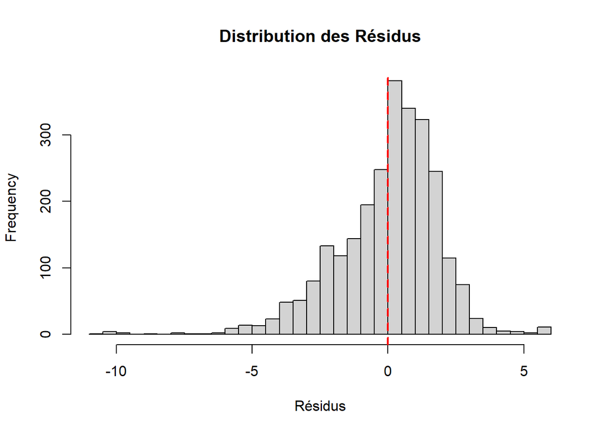

La ligne rouge représente la moyenne des résidus, elle est très proche de 0.

**Tests Statistiques**

**Test de Student (t-test)**

Hypothèses :

- $H_0$ : E(ε) = 0(moyenne des erreurs est nulle)
- $H_1$ : E(ε) ≠ 0 (présence d’un biais)

```
##
##  One Sample t-test
##
## data:  epsilon
## t = -2.7658e-09, df = 2624, p-value = 1
## alternative hypothesis: true mean is not equal to 0
## 95 percent confidence interval:
##  -0.07172264  0.07172264
## sample estimates:
##     mean of x
## -1.011642e-10
```

La **statistique du test** est extrêmement proche de zéro, indiquant que la différence entre la moyenne observée et zéro est négligeable.

La **p-value** très élevée (p = 1) signifie qu’il n’y a aucune preuve statistique contre l’hypothèse nulle E(ε) = 0.

**L’intervalle de confiance à 95%** est [-0.07172264, 0.07172264]. Cet intervalle contient zéro, ce qui confirme que la moyenne des résidus est compatible avec 0.

**Interprétation**

```
## [1] "Moyenne des erreurs : -1.17701483480305e-16"
```

**La moyenne des résidus** obtenue est -1.17701483480305e-16, soit approximativement 0. Ce résultat est conforme aux attentes en régression linéaire, où les résidus doivent en moyenne être proches de zéro.

#### 1.6.3 Homoscédasticité des résidus :

**Visualisation graphique**

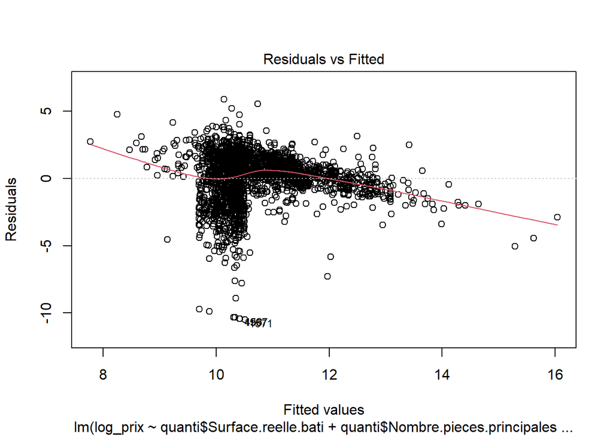

Les résidus ne présentent pas une tendance linéaire donc l’hypothèse d’homoscédasticité semble ne pas être respectée.

**Tests Statistiques**

**Test de Breusch-Pagan**

Hypothèses :

- $H_0$ : La variance des résidus est constante (homoscédasticité)
- $H_1$ : La variance des résidus n”est pas constante (hétéroscédasticité)

```
##
##  studentized Breusch-Pagan test
##
## data:  model1
## BP = 96.027, df = 7, p-value < 2.2e-16
```

Le test de Breusch-Pagan ne nous permet pas d’accepter l’hypothèse d’homoscédasticité.

#### 1.6.4 Corrélation des résidus

**on graphique : Corrélogramme**

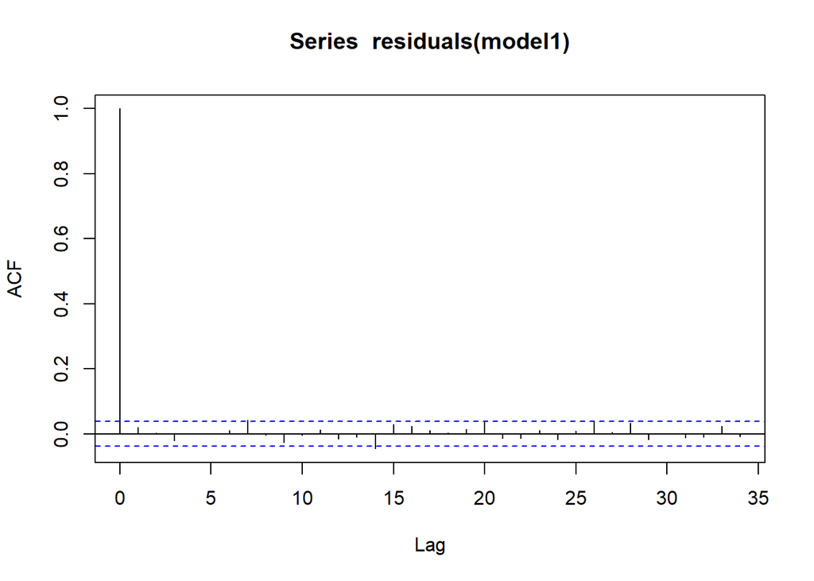

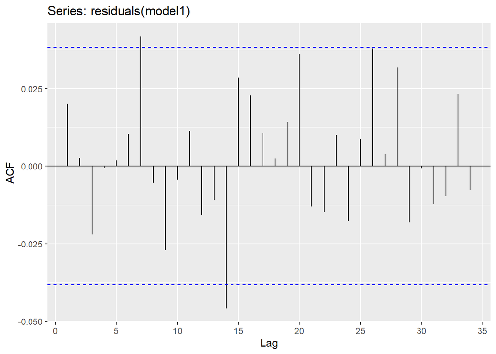

Le test montre que les résidus ne présentent pas d’autocorrélation significative, car la plupart des barres d’autocorrélation sont dans les bandes bleues (intervalle de confiance). Cela indique que le modèle explique correctement la structure des données, sans laisser de dépendance temporelle non prise en compte.

### Tests statistiques

**Test de Durbin-Watson**

Hypothèses :

- $H_0$ : Les résidus ne sont pas autocorrélés
- $H_1$ : Les résidus sont autocorrélés

```
##
##  Durbin-Watson test
##
## data:  model1
## DW = 1.9596, p-value = 0.1506
## alternative hypothesis: true autocorrelation is greater than 0
```

**La statistique DW** proche de 2 et la p-value (0.1506) indiquent qu’il n’y a pas d’autocorrélation significative entre les résidus.

**Test de Ljung-Box**

Hypothèse :

- $H_0$ : Les résidus ne sont pas autocorrélés
- $H_1$ : Les résidus sont autocorrélés

```
##
##  Box-Ljung test
##
## data:  residuals(model1)
## X-squared = 1.0619, df = 1, p-value = 0.3028
```

Au seuil de 5 %, les résidus **ne montrent pas d’autocorrélation significative**.  
Cela signifie que l’hypothèse d’indépendance des résidus est **raisonnablement respectée**.

**Test de Box-Pierce**

Hypothèses :

- $H_O$ : Les résidus ne sont pas autocorrélés (ils sont indépendants)
- $H_1$: Les résidus sont autocorrélés (présence d’une dépendance dans les erreurs).

```
## [1] "Box-Pierce p-value: 0.303053198038362"
```

P-value > 0.05, on conclut qu’il n’y a pas d’autocorrélation significative des résidus.

#### 1.6.5 Normalité des résidus

**Visualisation graphique**

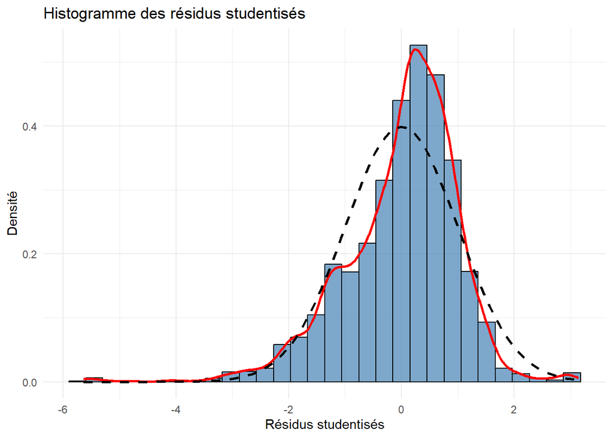

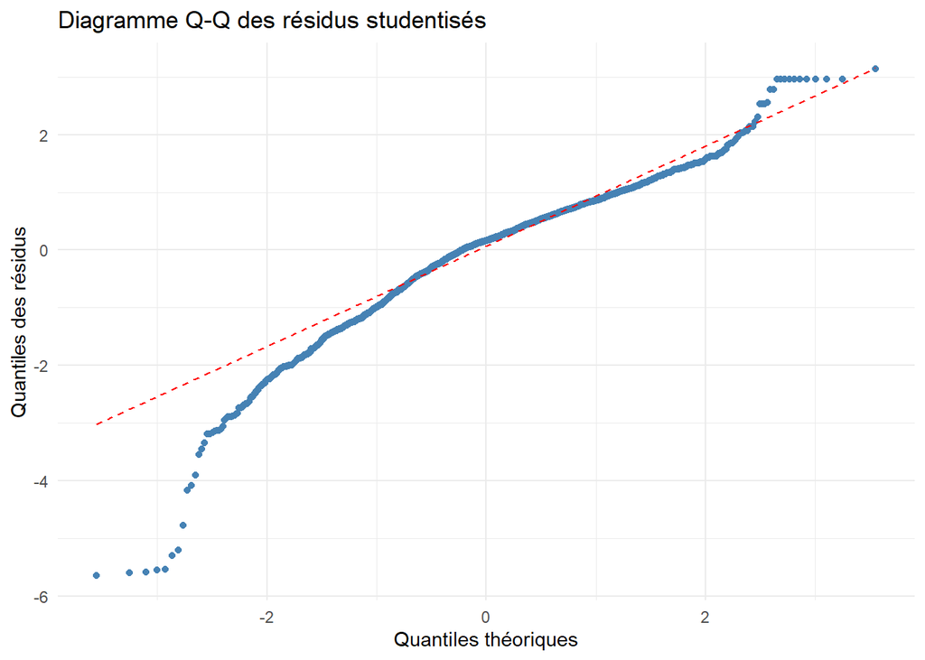

Interprétation :

- La courbe rouge (densité empirique) ne s’aligne pas avec la courbe (distribution normale théorique), la normalité des résidus est remise en question.
- les points s’éloignent de la ligne rouge, les résidus ne suivent pas une loi normale.

**Tests statistiques**

**Test de Shapiro-Wilk**

Hypothèses :

- $H_0$ : Le modèle suit une loi normale
- $H_1$ : Le modèle ne suit pas une loi normale

```
##
##  Shapiro-Wilk normality test
##
## data:  epsilon
## W = 0.95015, p-value < 2.2e-16
```

P-value < 0,05 donc nous concluons que **les résidus ne suivent pas une loi normale**.

**Test de normalité de Lilliefors**

Hypothèses :

- $H_0$: Le modèle suit une loi normale
- $H_1$ : Le modèle ne suit pas une loi normale.

```
## [1] "Lilliefors p-value: 2.45858755803321e-56"
```

P-value < 0.05, donc les résidus ne suivent pas une loi normale.

##### **Tableau récapitulatif de nos tests statistiques**

[output not shown]

### 1.7 - Détection des individus extrêmes (outliers)

Nous vérifions la présence des outliers dans notre modèle. Afin de les identifier, nous allons utiliser différentes approches.

#### 1.7.1 Détection des outliers via l’effet levier (Hat Values)

L’effet levier est mesuré par la matrice Hat :
$$H = X (X^T X)^{-1} X^T$$
où
$$H$$
représente la diagonale de la matrice Hat.

Une observation est considérée comme influente si :
$$H > \frac{2p}{n}$$

où : - $p$ est le nombre de paramètres du modèle (y compris l’intercept), - $n$ est la taille de l’échantillon.

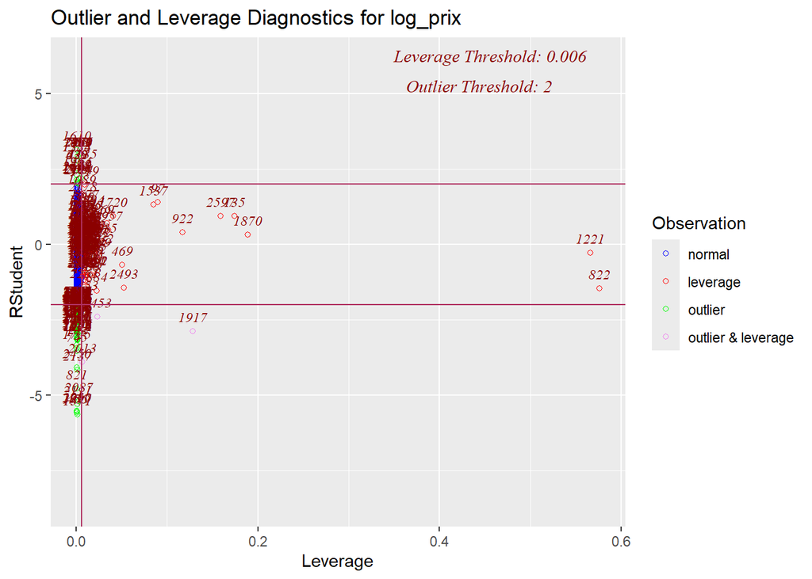

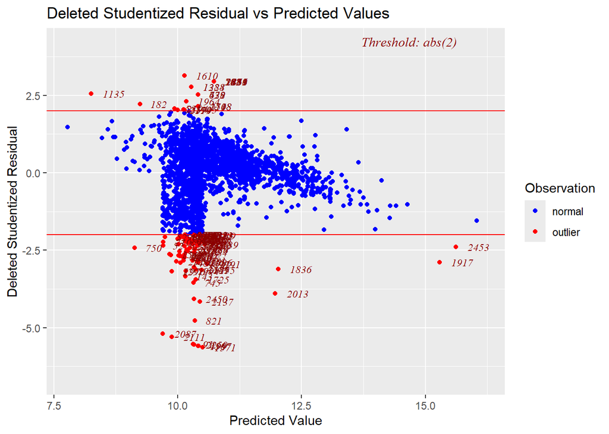

```
##   69   97  124  135  197  382  392  453  466  469  548  667  820  822  849  884
##   69   97  124  135  197  382  392  453  466  469  548  667  820  822  849  884
##  922 1046 1132 1221 1226 1299 1313 1431 1537 1573 1650 1720 1822 1834 1864 1870
##  922 1046 1132 1221 1226 1299 1313 1431 1537 1573 1650 1720 1822 1834 1864 1870
## 1917 1957 1960 1992 2002 2075 2232 2453 2493 2535 2597
## 1917 1957 1960 1992 2002 2075 2232 2453 2493 2535 2597
```

```
##      Min.   1st Qu.    Median      Mean   3rd Qu.      Max.
## 0.0005571 0.0008625 0.0015345 0.0030476 0.0024146 0.5758226
```

```
## [1] 0.01219048
```

#### 1.7.2 Détection via les résidus studentisés

Les résidus studentisés externes permettent de détecter les valeurs aberrantes :
$$t_i = \frac{e_{(i)}}{s_{(i)}
\sqrt{1 - h_i}}$$
où :

- $e_i$ est le résidu de l’observation $i$ _ $h_i$ est la valeur de levier, $s_{(i)}$ est l’écart-type des résidus calculé sans l’observation $i$.

Une observation est suspecte si $|t_i| > 3$.

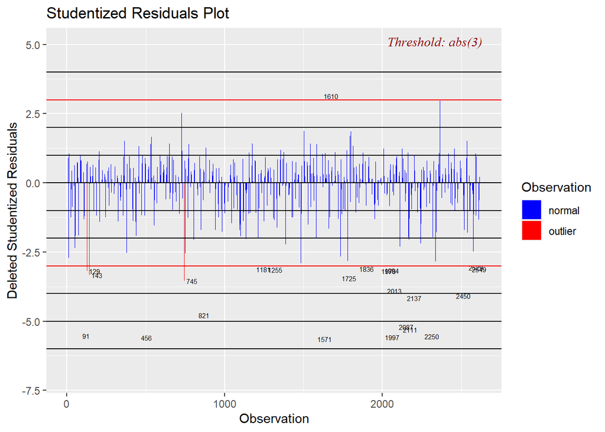

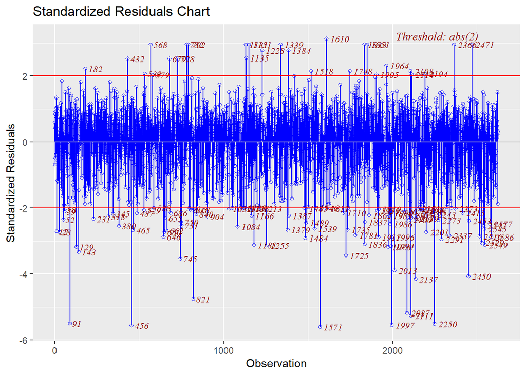

```
## Nombre d'outliers avec |résidu studentisé| > 2 : 126
```

```
## Nombre d'outliers sévères avec |résidu studentisé| > 3 : 23
```

#### 1.7.3 Détection des outliers via la distance de Cook

La distance de Cook mesure l’influence d’une observation sur l’ensemble du modèle :

$$D_i = \frac{\sum_{j=1}^{n} (\hat{Y}_j -
\hat{Y}_{j(i)})^2}{p \cdot \hat{\sigma}^2}$$
Une règle générale pour identifier les observations influentes :
$$D_i > \frac{4}{n}$$
où :

- $D_i$ est la distance de Cook pour l’observation $i$,
- $\hat{Y}_j$ est la prédiction avec tous les points,
- $\hat{Y}_{j(i)}$ est la prédiction sans l’observation $i$,
- $p$ est le nombre de paramètres du modèle,
- $\hat{\sigma}^2$ est la variance des résidus.

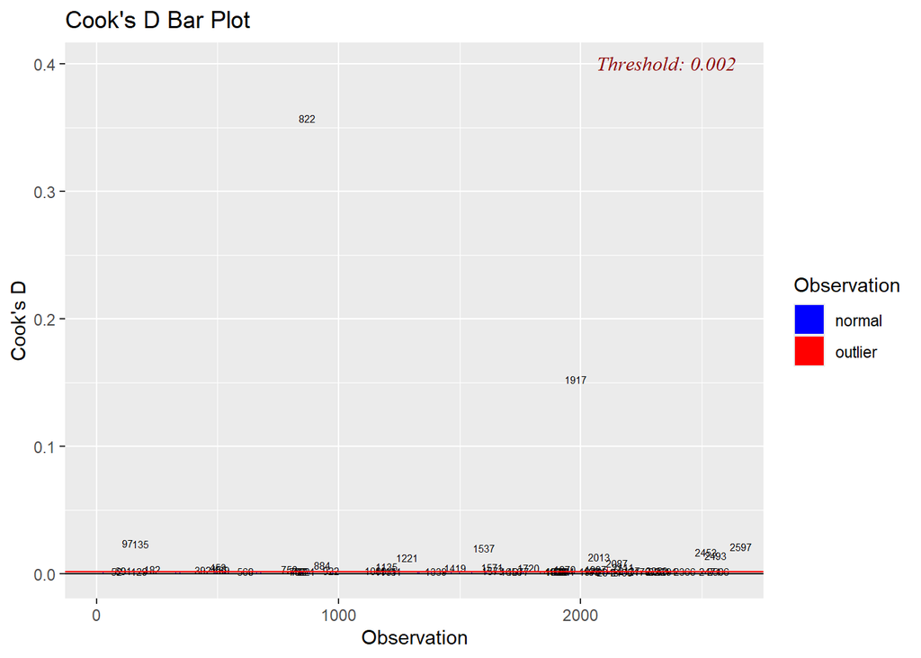

```
##   52   69   91   97  129  135  182  392  453  456  469  568  750  782  792  821
##   52   69   91   97  129  135  182  392  453  456  469  568  750  782  792  821
##  822  884  922 1089 1131 1135 1151 1221 1339 1419 1537 1571 1573 1650 1677 1720
##  822  884  922 1089 1131 1135 1151 1221 1339 1419 1537 1571 1573 1650 1677 1720
## 1833 1834 1836 1851 1864 1870 1917 1976 1994 1997 2013 2048 2087 2105 2111 2137
## 1833 1834 1836 1851 1864 1870 1917 1976 1994 1997 2013 2048 2087 2105 2111 2137
## 2178 2250 2261 2291 2366 2453 2471 2493 2506 2597
## 2178 2250 2261 2291 2366 2453 2471 2493 2506 2597
```

Les points qui dépassent la ligne rouge ont un effet disproportionné sur la régression. Ces points doivent être examinés individuellement pour voir s’ils sont des valeurs aberrantes ou des observations influentes.

#### 1.7.4 Analyse des DFBETAS (Influence sur les coefficients)

DFBETAS (Difference in Betas) mesure l’impact d’une observation sur un coefficient de régression spécifique.
$$DFBETAS_{ij} = \frac{\beta_j - \beta_{j(i)}}{s_{(i)} \sqrt{C_{jj}}}$$
où :

- $\beta_j$ est le coefficient estimé avec tous les points,
- $\beta_{j(i)}$ est le coefficient estimé sans l’observation $i$,
- $C_{jj}$ est l’élément diagonal de la matrice $(X^T X)^{-1}$. Une valeur $|DFBETAS_{ij}| > 2 / \sqrt{n}$ indique une forte influence.

```
## Nombre d'observations influentes selon DFBETAS : 294
```

#### 1.7.5 Analyse des DFFITS (Influence sur les prédictions)

DFFITS (Difference in Fits) indique si une observation change fortement la valeur prédite du modèle.

$$DFFITS_i = \frac{\hat{Y}_i -
\hat{Y}_{i(i)}}{s_{(i)} \sqrt{h_i}}$$
où :

- $\hat{Y}_i$ est la prédiction avec tous les points,
- $\hat{Y}_{i(i)}$ est la prédiction sans l’observation $i$.

Une observation est considérée comme influente si :
$$|DFFITS_i| > 2 \frac{\sqrt{p}}{\sqrt{n}}$$

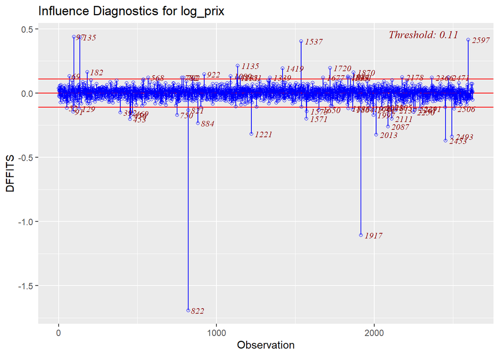

```
## Nombre d'observations influentes selon DFFITS : 66
```

- Les observations influentes selon DFFITS sont celles qui changent significativement la valeur prédite.
- Certaines observations apparaissent dans les deux listes (DFBETAS & DFFITS), ce qui indique qu’elles affectent à la fois les coefficients et les prédictions.
- Les points au-dessus de la ligne rouge dans le graphique DFFITS sont ceux qui ont le plus grand impact sur les valeurs prédites.

**Resumé des influences**

| Critère | Nombre |
| --- | --- |
| Outliers (Résidus Studentisés > 2) | 126 |
| Outliers Sévères (Résidus Studentisés > 3) | 23 |
| Observations Influentes (DFBETAS) | 294 |
| Observations Influentes (DFFITS) | 66 |

### 1.8 Suppression des valeurs extrêmes et création du nouveau modèle

Suite à la visualisation de nos valeurs extrême, on peut créer un nouveau modèle en les supprimants afin de voir si il est possible de faire une meilleure étude de nos données.

**Modèle Initial**

```
##
## Call:
## lm(formula = log_prix ~ quanti$Surface.reelle.bati + quanti$Nombre.pieces.principales +
##     quanti$Surface.terrain + quanti$Code.postal + quanti$Nombre.de.lots +
##     quanti$Surface.Carrez.du.1er.lot + quanti$Code.type.local,
##     data = sym_quanti)
##
## Residuals:
##      Min       1Q   Median       3Q      Max
## -10.5062  -0.9692   0.3030   1.2274   5.8775
##
## Coefficients:
##                                    Estimate Std. Error t value Pr(>|t|)
## (Intercept)                       6.537e+01  9.415e+00   6.943 4.83e-12 ***
## quanti$Surface.reelle.bati        1.319e-04  9.529e-05   1.384  0.16644
## quanti$Nombre.pieces.principales  7.369e-01  4.149e-02  17.758  < 2e-16 ***
## quanti$Surface.terrain            3.651e-06  4.848e-06   0.753  0.45145
## quanti$Code.postal               -9.231e-04  1.483e-04  -6.226 5.56e-10 ***
## quanti$Nombre.de.lots             1.352e-01  4.903e-02   2.757  0.00588 **
## quanti$Surface.Carrez.du.1er.lot -1.232e-03  4.500e-03  -0.274  0.78435
## quanti$Code.type.local            1.360e+00  9.315e-02  14.599  < 2e-16 ***
## ---
## Signif. codes:  0 '***' 0.001 '**' 0.01 '*' 0.05 '.' 0.1 ' ' 1
##
## Residual standard error: 1.877 on 2617 degrees of freedom
## Multiple R-squared:  0.1599, Adjusted R-squared:  0.1577
## F-statistic: 71.16 on 7 and 2617 DF,  p-value: < 2.2e-16
```

**Modèle sans Outliers (DFBETAS)**

```
##
## Call:
## lm(formula = log_prix ~ ., data = base_sans_dfbetas)
##
## Residuals:
##     Min      1Q  Median      3Q     Max
## -6.2739 -0.8357  0.2235  1.0812  5.8072
##
## Coefficients:
##                             Estimate Std. Error t value Pr(>|t|)
## (Intercept)                4.786e+01  8.796e+00   5.442 5.84e-08 ***
## Surface.reelle.bati       -1.424e-03  9.720e-04  -1.465   0.1430
## Nombre.pieces.principales  9.152e-01  4.816e-02  19.001  < 2e-16 ***
## Surface.terrain           -3.499e-05  7.516e-06  -4.655 3.42e-06 ***
## Code.postal               -6.559e-04  1.385e-04  -4.736 2.31e-06 ***
## Nombre.de.lots             1.042e-01  5.137e-02   2.027   0.0427 *
## Surface.Carrez.du.1er.lot -3.605e-03  6.043e-03  -0.597   0.5508
## Code.type.local            1.670e+00  9.387e-02  17.786  < 2e-16 ***
## ---
## Signif. codes:  0 '***' 0.001 '**' 0.01 '*' 0.05 '.' 0.1 ' ' 1
##
## Residual standard error: 1.531 on 2323 degrees of freedom
## Multiple R-squared:  0.2401, Adjusted R-squared:  0.2378
## F-statistic: 104.8 on 7 and 2323 DF,  p-value: < 2.2e-16
```

### **Comparaison des modèles (avec et sans outlier)**

[output not shown]

La suppression des outliers a permi une amélioration de 8% du modèle initial . Les variables non significatives pourraient être retirées pour optimiser le modèle.

### 1.9 Analyse de la multicolinéarité

#### 1.9.1 Variance Inflation Factor (VIF)

Le Variance Inflation Factor (VIF) mesure dans quelle mesure la variance d’un coefficient de régression est augmentée à cause de la colinéarité avec les autres variables explicatives. Une valeur élevée indique une forte multicolinéarité.
$$\text{VIF}_j = \frac{1}{1 - R_j^2}$$

où $R_j^2$ est le coefficient de détermination obtenu en régressant la variable $X_j$ sur toutes les autres variables explicatives du modèle.

```
##       quanti$Surface.reelle.bati quanti$Nombre.pieces.principales
##                         1.035922                         2.692530
##           quanti$Surface.terrain               quanti$Code.postal
##                         1.030793                         1.116126
##            quanti$Nombre.de.lots quanti$Surface.Carrez.du.1er.lot
##                         1.350493                         1.124927
##           quanti$Code.type.local
##                         2.916033
```

Les valeurs de VIF sont globalement inférieures à 3, ce qui indique une absence de multicolinéarité problématique dans le modèle. Les variables “Nombre de pièces principales” et “Code type local” présentent une colinéarité modérée mais restent en dessous des seuils critiques (VIF < 5). Le modèle peut donc être estimé sans risque majeur d’instabilité des coefficients.

#### 19.2 Tolérance

La tolérance est l’inverse du VIF et représente la proportion de variance d’une variable qui n’est pas expliquée par les autres variables du modèle.

$$\text{Tolérance}_j = \frac{1}{\text{VIF}_j} = 1 - R_j^2$$

```
##       quanti$Surface.reelle.bati quanti$Nombre.pieces.principales
##                        0.9653238                        0.3713979
##           quanti$Surface.terrain               quanti$Code.postal
##                        0.9701267                        0.8959563
##            quanti$Nombre.de.lots quanti$Surface.Carrez.du.1er.lot
##                        0.7404703                        0.8889463
##           quanti$Code.type.local
##                        0.3429317
```

Toutes les valeurs de tolérance sont proches de 1 saut Code.type.local et Nombre.pieces.principales , indiquant que certaines variables ont une faible corrélation avec les autres. Cela signifie que le modèle est bien spécifié et que les coefficients de régression sont fiables et interprétables.

## 2 - Modèle Linéaire Généralisé (GLM) :

### 2.1 La théorie

**Présentation du GLM**

Le **Modèle Linéaire Généralisé** (*Generalized Linear Model*, GLM) étend le modèle linéaire classique à des distributions non gaussiennes en utilisant la méthode des **moindres carrés itérativement repondérés** (IRLS) pour l’estimation et le test des hypothèses.

#### 2.1.1 Matrice

La matrice $X$ rassemble les variables explicatives pour $n$ observations et $p$ prédicteurs :

$$X = \begin{pmatrix}
1 & x_{1,1} & \cdots & x_{1,p} \\
\vdots & \ddots & & \vdots \\
1 & x_{n,1} & \cdots & x_{n,p}
\end{pmatrix}$$

#### 2.1.2 Famille exponentielle :

La densité conditionnelle de $Y \mid X = x_i$ appartient à la **famille exponentielle** :

$$f_{Y \mid X=x_i}(y_i) =
\exp\!\left(\frac{y_i\,\theta_i - b(\theta_i)}{a_i(\phi)} + c(y_i,
\phi)\right)$$

où :

- $\theta_i$ : paramètre naturel d’intérêt,
- $\phi$ : paramètre de nuisance (supposé connu), avec $a_i(\phi) = \phi$,
- $a,\, b,\, c$ : fonctions connues caractérisant la famille.

#### 2.1.3 Espérance et variance conditionnelles

$$\mu_i = \mathbb{E}(Y \mid X = x_i) =
g^{-1}(\eta_i), \qquad \eta_i = X_i^\top \beta$$

$$\text{Var}(Y \mid X = x_i) =
b''(g(\mu_i))\,\phi$$

#### 2.1.4 Écriture du modèle

$$y_i = g^{-1}(X_i^\top \beta) +
\varepsilon_i$$

La **fonction de lien** $g$ connecte l’espérance conditionnelle $\mu_i$ au prédicteur linéaire $\eta_i = X_i^\top \beta$.

### 2.2 Types de modèles GLM

Le choix de la famille et du lien dépend de la nature de la variable réponse :

| Variable réponse | Famille | Lien canonique | Lien alternatif |
| --- | --- | --- | --- |
| Continue (symétrique) | Gaussienne | Identité | log |
| Continue (asymétrique $>0$) | Gamma | Inverse | log |
| Continue (0 ; 1) | Beta | Logit | — |
| Binaire / proportions | Binomiale | Logit | Probit, complementary log-log |
| Comptage | Poisson | Log | — |
| Comptage (surdispersion) | Binomiale négative | Log | — |

**Conditions d’application communes**

Pour tous ces modèles, il faut veiller à :

1. **Indépendance** des observations (et des erreurs),
2. **Absence de valeurs aberrantes** influentes,
3. **Absence de multicolinéarité** excessive entre les prédicteurs.

### 2.3 Algorithme IRLS

Le GLM est estimé par **vraisemblance maximale** via l’algorithme des moindres carrés itérativement repondérés (IRLS) :

**Initialisation :** $\mu^{(0)} = \bar{y}$, $\eta^{(0)} = g(\mu^{(0)})$

**À chaque itération $t$ :**

1. **Variable de travail ajustée :**
   $$z_i^{(t)} = \eta_i^{(t)} + (y_i -
   \mu_i^{(t)})\,g'(\mu_i^{(t)})$$
2. **Matrice de poids :**
   $$W_{ii}^{(t)} =
   \frac{1}{V(\mu_i^{(t)})\,[g'(\mu_i^{(t)})]^2}$$
3. **MCO pondérés :**
   $$\hat{\beta}^{(t+1)} = \left(X^\top W^{(t)}
   X\right)^{-1} X^\top W^{(t)} z^{(t)}$$
4. **Mise à jour :** $\eta^{(t+1)} = X\hat{\beta}^{(t+1)}$, $\mu^{(t+1)} = g^{-1}(\eta^{(t+1)})$

**Convergence :** $\max|\hat\beta^{(t+1)} - \hat\beta^{(t)}| < \varepsilon$

> **Remarque :** Pour le modèle gaussien avec lien identité, $g'(\mu)=1$ et $V(\mu)=1$, donc $W = I$ et l’algorithme converge en **une seule itération**, ce qui redonne exactement les MCO ordinaires.

### 2.4 Déviance et qualité d’ajustement

La **déviance** généralise la somme des carrés résiduels :

$$D = 2\,[\ell(\hat\mu_{\text{sat}}) -
\ell(\hat\mu)]$$

où $\ell(\hat\mu_{\text{sat}})$ est la log-vraisemblance du modèle saturé.

L’**AIC** (Critère d’Akaike) permet de comparer des modèles :

$$\text{AIC} = -2\ell(\hat\beta) +
2p$$

### 2.5 Application

#### 2.5.1 Application du GLM

On peut faire le glm :

##### Modèle gaussien avec link = log

### Modèle 2 : GLM gaussien avec lien logarithmique

Le modèle généralisé utilisé est :

$$g(\mu_i) = \log(\mu_i)$$

avec :

$$Y_i \sim \mathcal{N}(\mu_i, \sigma^2)$$

La relation entre la moyenne et les variables explicatives est :

$$\log(\mathbb{E}[Prix_i]) =
\beta_0
+ \beta_1 \cdot \text{Surface.reelle.bati}_i
+ \beta_2 \cdot \text{Nombre.pieces.principales}_i
+ \beta_3 \cdot \text{Surface.terrain}_i
+ \beta_4 \cdot \text{Code.postal}_i
+ \beta_5 \cdot \text{Nombre.de.lots}_i
+ \beta_6 \cdot \text{Surface.Carrez.du.1er.lot}_i
+ \beta_7 \cdot \text{Code.type.local}_i$$

```
##
## Call:
## glm(formula = log_prix ~ ., family = gaussian(link = "log"),
##     data = sym_quanti)
##
## Coefficients:
##                             Estimate Std. Error t value Pr(>|t|)
## (Intercept)                7.655e+00  8.801e-01   8.698  < 2e-16 ***
## Surface.reelle.bati        9.627e-06  6.924e-06   1.390   0.1645
## Nombre.pieces.principales  6.174e-02  3.444e-03  17.925  < 2e-16 ***
## Surface.terrain            2.541e-07  4.622e-07   0.550   0.5826
## Code.postal               -8.865e-05  1.386e-05  -6.395 1.89e-10 ***
## Nombre.de.lots             8.876e-03  4.095e-03   2.167   0.0303 *
## Surface.Carrez.du.1er.lot -5.538e-05  3.716e-04  -0.149   0.8815
## Code.type.local            1.178e-01  8.079e-03  14.587  < 2e-16 ***
## ---
## Signif. codes:  0 '***' 0.001 '**' 0.01 '*' 0.05 '.' 0.1 ' ' 1
##
## (Dispersion parameter for gaussian family taken to be 3.508609)
##
##     Null deviance: 10856.2  on 2624  degrees of freedom
## Residual deviance:  9182.1  on 2617  degrees of freedom
## AIC: 10754
##
## Number of Fisher Scoring iterations: 5
```

#### Modèle Gamma avec lien inverse

```
##
## Call:
## glm(formula = log_prix ~ ., family = Gamma(link = "inverse"),
##     data = sym_quanti)
##
## Coefficients:
##                             Estimate Std. Error t value Pr(>|t|)
## (Intercept)               -4.024e-01  8.486e-02  -4.742 2.23e-06 ***
## Surface.reelle.bati       -7.248e-07  6.668e-07  -1.087   0.2772
## Nombre.pieces.principales -5.648e-03  3.268e-04 -17.284  < 2e-16 ***
## Surface.terrain           -2.555e-08  4.459e-08  -0.573   0.5667
## Code.postal                8.300e-06  1.336e-06   6.211 6.11e-10 ***
## Nombre.de.lots            -9.610e-04  3.859e-04  -2.490   0.0128 *
## Surface.Carrez.du.1er.lot  1.348e-05  3.546e-05   0.380   0.7039
## Code.type.local           -1.071e-02  7.730e-04 -13.856  < 2e-16 ***
## ---
## Signif. codes:  0 '***' 0.001 '**' 0.01 '*' 0.05 '.' 0.1 ' ' 1
##
## (Dispersion parameter for Gamma family taken to be 0.03266417)
##
##     Null deviance: 131.49  on 2624  degrees of freedom
## Residual deviance: 117.29  on 2617  degrees of freedom
## AIC: 11657
##
## Number of Fisher Scoring iterations: 4
```

#### Modèle Gamma avec lien logarithmique

```
##
## Call:
## glm(formula = log_prix ~ ., family = Gamma(link = "log"), data = sym_quanti)
##
## Coefficients:
##                             Estimate Std. Error t value Pr(>|t|)
## (Intercept)                7.505e+00  9.060e-01   8.283  < 2e-16 ***
## Surface.reelle.bati        9.909e-06  9.170e-06   1.081  0.27994
## Nombre.pieces.principales  6.777e-02  3.993e-03  16.971  < 2e-16 ***
## Surface.terrain            3.539e-07  4.666e-07   0.759  0.44814
## Code.postal               -8.650e-05  1.427e-05  -6.063 1.53e-09 ***
## Nombre.de.lots             1.459e-02  4.718e-03   3.092  0.00201 **
## Surface.Carrez.du.1er.lot -2.162e-04  4.331e-04  -0.499  0.61764
## Code.type.local            1.239e-01  8.964e-03  13.822  < 2e-16 ***
## ---
## Signif. codes:  0 '***' 0.001 '**' 0.01 '*' 0.05 '.' 0.1 ' ' 1
##
## (Dispersion parameter for Gamma family taken to be 0.03260826)
##
##     Null deviance: 131.49  on 2624  degrees of freedom
## Residual deviance: 116.60  on 2617  degrees of freedom
## AIC: 11641
##
## Number of Fisher Scoring iterations: 5
```

**Comparaison des modèles**

|  | AIC | BIC | RMSE |
| --- | --- | --- | --- |
| LM | 10763.86 | 10816.71 | 1.862713 |
| GLM (Gamma - Inverse) | 11656.58 | 11709.43 | 1.882803 |
| GLM (Gaussien - log) | 10754.38 | 10807.23 | 1.870275 |
| GLM (Gamma - Log) | 11640.80 | 11693.66 | 1.872980 |

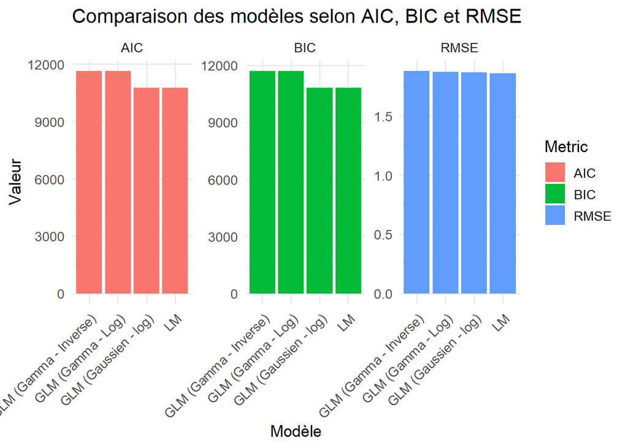

Le GLM Gaussien avec lien log a les meilleurs scores en terme de AIC et BIC, ce qui suggère un meilleur compromis entre qualité d’ajustement et complexité du modèle tandisque la régression linéaire multiple reste légèrement meilleure en termes d’erreur quadratique moyenne.

**Test de Vuong**

On va utiliser le test de vuong sur les deux modèles ayant l’AIC et le BIC le plus faible pour confirmer le choix de notre modèle final.

```
##
## Model 1
##  Class: lm
##  Call: lm(formula = log_prix ~ quanti$Surface.reelle.bati + quanti$Nombre.pieces.principales + ...
##
## Model 2
##  Class: glm
##  Call: glm(formula = log_prix ~ ., family = gaussian(link = "log"), ...
##
## Variance test
##   H0: Model 1 and Model 2 are indistinguishable
##   H1: Model 1 and Model 2 are distinguishable
##     w2 = 1.199,   p = <2e-16
##
## Non-nested likelihood ratio test
##   H0: Model fits are equal for the focal population
##   H1A: Model 1 fits better than Model 2
##     z = -0.084,   p = 0.534
##   H1B: Model 2 fits better than Model 1
##     z = -0.084,   p = 0.4663
```

Les modèles sont statistiquement différents en termes de structure de variance.

En termes de qualité d’ajustement globale, les deux modèles sont équivalents pour la population cible.

Le GLM avec lien log peut être préféré si les résidus du modèle linéaire montrent une hétéroscédasticité ou une asymétrie

#### 2.5.2 GLM à la main — algorithme IRLS

### Exécution et résultats

##### Modèle gaussien avec link = log

[output not shown]

##### Modèle gamma avec link = log

```
## Itération   1 | max|Δβ| = 7.468e+00
## Itération   2 | max|Δβ| = 4.396e-02
## Itération   3 | max|Δβ| = 7.014e-03
## Itération   4 | max|Δβ| = 8.582e-05
## Itération   5 | max|Δβ| = 1.790e-05
## Itération   6 | max|Δβ| = 7.259e-07
## Itération   7 | max|Δβ| = 8.289e-08
## Itération   8 | max|Δβ| = 4.112e-09
##
## ✓ Convergé en 8 itérations.
##
## ───────────────────────────────────────────────────────
## GLM à la main | Family: Gamma | Link: log
## ───────────────────────────────────────────────────────
## Terme                   Estimate   Std.Err   t value    Pr(>|t|)
## -----------------------------------------------------------------
## (Intercept)               7.5047    9.4115     0.797      0.4253
## Surface.reelle.bati       0.0000    0.0001     0.104      0.9172
## Nombre.pieces.principales    0.0678    0.0415     1.634      0.1024
## Surface.terrain           0.0000    0.0000     0.073      0.9418
## Code.postal              -0.0001    0.0001    -0.584      0.5595
## Nombre.de.lots            0.0146    0.0490     0.298      0.7660
## Surface.Carrez.du.1er.lot   -0.0002    0.0045    -0.048      0.9617
## Code.type.local           0.1239    0.0931     1.331      0.1834
## -----------------------------------------------------------------
## Déviance résiduelle : 9208.6382  (ddl: 2617)
## Déviance nulle      : 10856.1525  (ddl: 2624)
## AIC                 : 2633.0000
## Signif. codes: 0 '***' 0.001 '**' 0.01 '*' 0.05 ' '
```

```
## === Différence maximale entre les coefficients ===
```

```
## max |β_main - β_glm| = 5.78e+01
```

[output not shown]

### 2.6 Diagnostics du modèle :

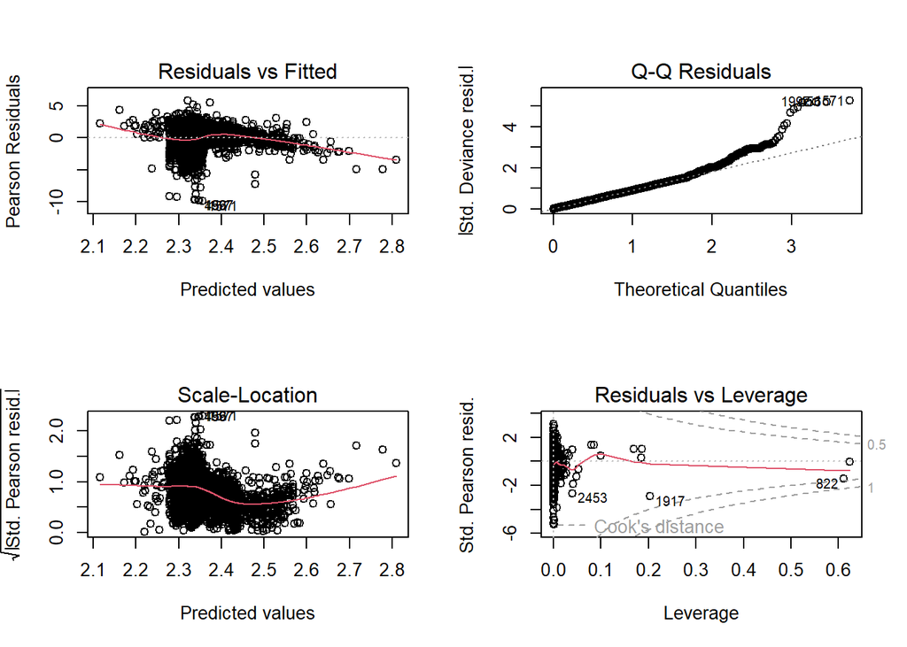

Diagnostics du modèle gaussien

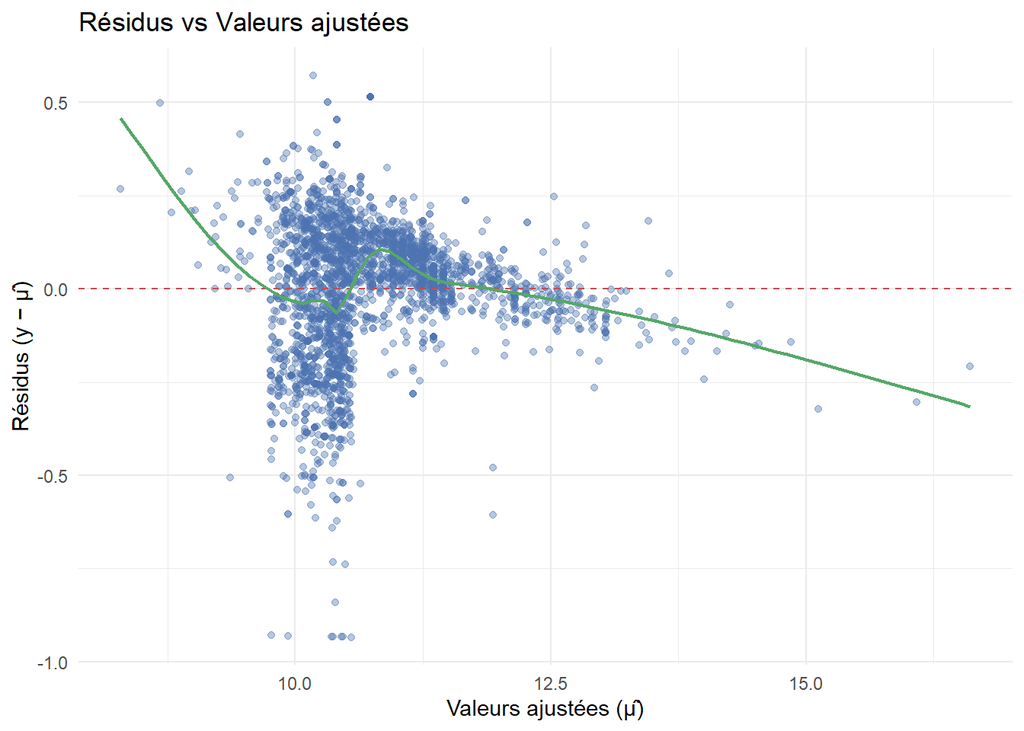

Résidus vs valeurs ajustées (GLM à la main)

### 2.8 Problèmes de multicolinéarité

La multicolinéarité correspond à une situation où les données contiennent des variables prédictives fortement corrélées.

```
##       Surface.reelle.bati Nombre.pieces.principales           Surface.terrain
##                  1.045128                  2.627962                  1.034077
##               Code.postal            Nombre.de.lots Surface.Carrez.du.1er.lot
##                  1.117240                  1.377590                  1.171395
##           Code.type.local
##                  2.831657
```

$$RSS = \sum (y_{i} - \hat
y_{i})^²$$

avec $y_{i}$ la valeur de réponse réellement pour la ième observation et $\hat y_{i}$ la valeur de réponse prédite basée sur le modèle de régression linéaire multiple